# RST Data checks - DB vs EDI

Badhia Yunes Katz

The purpose of this markdown is to compare the data that we have in jpe database and EDI. Data is being queried directly from the database and from EDI, this script can be used to check most up to date uploads.

Database tables are be viewed first, then data is compared by stream

# catch table

```
##         id                          catch_raw_id trap_location_id       date
## 1 44635223 {292A0CCD-FB5F-11D4-B974006008C01BCF}               14 1999-01-20
## 2 44635224 {292A0CCF-FB5F-11D4-B974006008C01BCF}               14 1999-01-20
## 3 44635225 {292A0CD3-FB5F-11D4-B974006008C01BCF}               14 1999-01-20
## 4 44635226 {292A0CD2-FB5F-11D4-B974006008C01BCF}               14 1999-01-20
## 5 44635227 {292A0CD1-FB5F-11D4-B974006008C01BCF}               14 1999-01-20
## 6 44635228 {292A0CD0-FB5F-11D4-B974006008C01BCF}               14 1999-01-20
##   count run_id lifestage_id adipose_clipped dead fork_length weight
## 1     2      3            4           FALSE   NA          34      0
## 2    18      3            4           FALSE   NA          36      0
## 3     2      3            4           FALSE   NA          40      0
## 4    10      3            4           FALSE   NA          39      0
## 5    12      3            4           FALSE   NA          38      0
## 6    22      3            4           FALSE   NA          37      0
##   actual_count          updated_at
## 1           NA 2025-06-03 19:10:04
## 2           NA 2025-06-03 19:10:04
## 3           NA 2025-06-03 19:10:04
## 4           NA 2025-06-03 19:10:04
## 5           NA 2025-06-03 19:10:04
## 6           NA 2025-06-03 19:10:04
```

```
##  [1] "id"               "catch_raw_id"     "trap_location_id" "date"
##  [5] "count"            "run_id"           "lifestage_id"     "adipose_clipped"
##  [9] "dead"             "fork_length"      "weight"           "actual_count"
## [13] "updated_at"
```

streams in catch table

```
##  [1] 14 51  8  9 56  6 52 55 25 18 24 31 49 47 48 57  2 15  5 74 75 76 77 78 79
```

date range

```
## [1] "1998-10-25" "2025-05-23"
```

# trap table

```
##        id trap_location_id trap_visit_id visit_type_id trap_visit_time_start
## 1 2004139                2          <NA>            NA   1998-08-31 07:50:00
## 2 2004140                2          <NA>            NA   1998-09-01 10:10:00
## 3 2004141                2          <NA>            NA   1998-09-02 10:31:00
## 4 2004142                2          <NA>            NA   1998-09-03 09:37:00
## 5 2004143                2          <NA>            NA   1998-09-08 09:37:00
## 6 2004144                2          <NA>            NA   1998-09-09 10:09:00
##   trap_visit_time_end trap_functioning_id in_half_cone_configuration
## 1 1998-09-01 10:10:00                   2                      FALSE
## 2 1998-09-02 10:31:00                   2                      FALSE
## 3 1998-09-03 09:37:00                   2                      FALSE
## 4 1998-09-04 10:09:00                   2                      FALSE
## 5 1998-09-09 10:09:00                   2                      FALSE
## 6 1998-09-10 09:30:00                   2                      FALSE
##   fish_processed_id rpm_start rpm_end total_revolutions debris_volume
```

[output cut: 20 more lines]

```
##  [1] "id"                         "trap_location_id"
##  [3] "trap_visit_id"              "visit_type_id"
##  [5] "trap_visit_time_start"      "trap_visit_time_end"
##  [7] "trap_functioning_id"        "in_half_cone_configuration"
##  [9] "fish_processed_id"          "rpm_start"
## [11] "rpm_end"                    "total_revolutions"
## [13] "debris_volume"              "debris_level_id"
## [15] "discharge"                  "water_velocity"
## [17] "water_temp"                 "turbidity"
## [19] "include"                    "updated_at"
## [21] "updated_by"
```

date range

- `trap_visit_start`

```
## [1] "1998-08-31 07:50:00 UTC" "2025-05-23 10:51:30 UTC"
```

- `trap_visit_end`

```
## [1] "1998-09-01 10:10:00 UTC" "2025-04-17 10:45:04 UTC"
```

# release table

```
##      id trap_location_id release_id       date_released run_id
## 1 63921                9        271 2022-03-08 13:20:19      2
## 2 63922                9        272 2023-01-24 12:00:19      2
## 3 63014               50        266 2023-03-08 13:30:12      3
## 4 63015               50        265 2023-03-08 13:30:12      3
## 5 68701               NA          1 2016-02-10 08:00:44      3
## 6 68702               NA        256 2016-02-17 10:00:44      3
##   median_fork_length_released lifestage_id origin_id number_released
## 1                          NA           NA         1             185
## 2                          NA           NA         1              71
## 3                          NA           NA         1             290
## 4                          NA           NA         2             509
## 5                          NA            4         2             358
## 6                          NA            7         2             457
##            updated_at updated_by
## 1 2025-06-09 09:05:14   AdminJPE
## 2 2025-06-09 09:05:14   AdminJPE
## 3 2025-06-09 09:00:13   AdminJPE
## 4 2025-06-09 09:00:13   AdminJPE
## 5 2025-06-16 09:13:17   AdminJPE
## 6 2025-06-16 09:13:17   AdminJPE
```

```
##  [1] "id"                          "trap_location_id"
##  [3] "release_id"                  "date_released"
##  [5] "run_id"                      "median_fork_length_released"
##  [7] "lifestage_id"                "origin_id"
##  [9] "number_released"             "updated_at"
## [11] "updated_by"
```

date range

```
## [1] "1999-02-04 17:00:00 UTC" "2025-04-10 10:12:00 UTC"
```

# recaptured_fish table

```
##       id trap_location_id catch_raw_id       date count run_id lifestage_id
## 1 234566               14           NA 2003-12-04     3     NA           NA
## 2 234567               15           NA 2003-12-04     6     NA           NA
## 3 234568               15           NA 2003-12-05     0     NA           NA
## 4 234569               14           NA 2003-12-05     0     NA           NA
## 5 234570               15           NA 2003-12-06     0     NA           NA
## 6 234571               14           NA 2003-12-06     0     NA           NA
##   adipose_clipped dead fork_length weight release_id          updated_at
## 1              NA   NA        34.0     NA     CLR171 2025-06-03 19:15:37
## 2              NA   NA        33.5     NA     CLR172 2025-06-03 19:15:37
## 3              NA   NA          NA     NA     CLR172 2025-06-03 19:15:37
## 4              NA   NA          NA     NA     CLR171 2025-06-03 19:15:37
## 5              NA   NA          NA     NA     CLR172 2025-06-03 19:15:37
## 6              NA   NA          NA     NA     CLR171 2025-06-03 19:15:37
```

```
##  [1] "id"               "trap_location_id" "catch_raw_id"     "date"
##  [5] "count"            "run_id"           "lifestage_id"     "adipose_clipped"
##  [9] "dead"             "fork_length"      "weight"           "release_id"
## [13] "updated_at"
```

date range

```
## [1] "2003-12-04" "2025-03-29"
```

## Exploration per stream

### Battle/Clear Creek

#### catch

**- Findings catch:** - same date range, just off by a moth - forklength max of EDI is higher - lifestage is challenging to compare since there are more categories on edi

- DB date range

```
## [1] "1998-10-25" "2025-04-02"
```

- EDI date range

```
## [1] "1998-09-01" "2025-04-02"
```

Checking stations of EDI to be battle and clear

```
## [1] "upper battle creek"       "lower battle creek"
## [3] "lower clear creek"        "upper clear creek"
## [5] NA                         "power house battle creek"
```

*fork_length*

EDI

- 0.1 % of values in the `fork_length` column are NA.

```
##    Min. 1st Qu.  Median    Mean 3rd Qu.    Max.    NA's
##    0.00   34.00   36.00   43.96   43.00  730.00     519
```

DB

- 0 % of values in the `fork_length` column are NA.

```
##    Min. 1st Qu.  Median    Mean 3rd Qu.    Max.    NA's
##    0.00   34.00   36.00   37.38   38.00  214.00     165
```

exploration plots

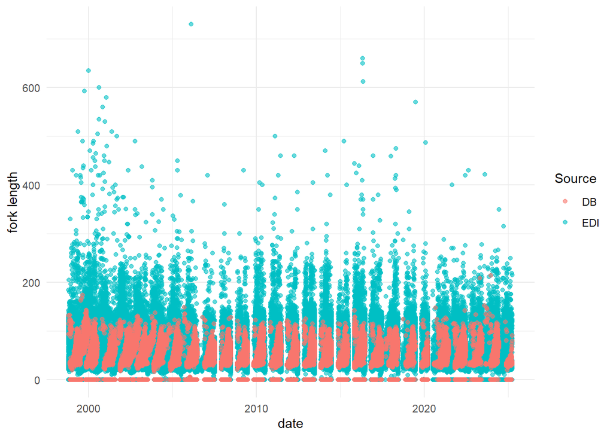

- 0 % of values in the `lifestage_id` column from the database are NA.

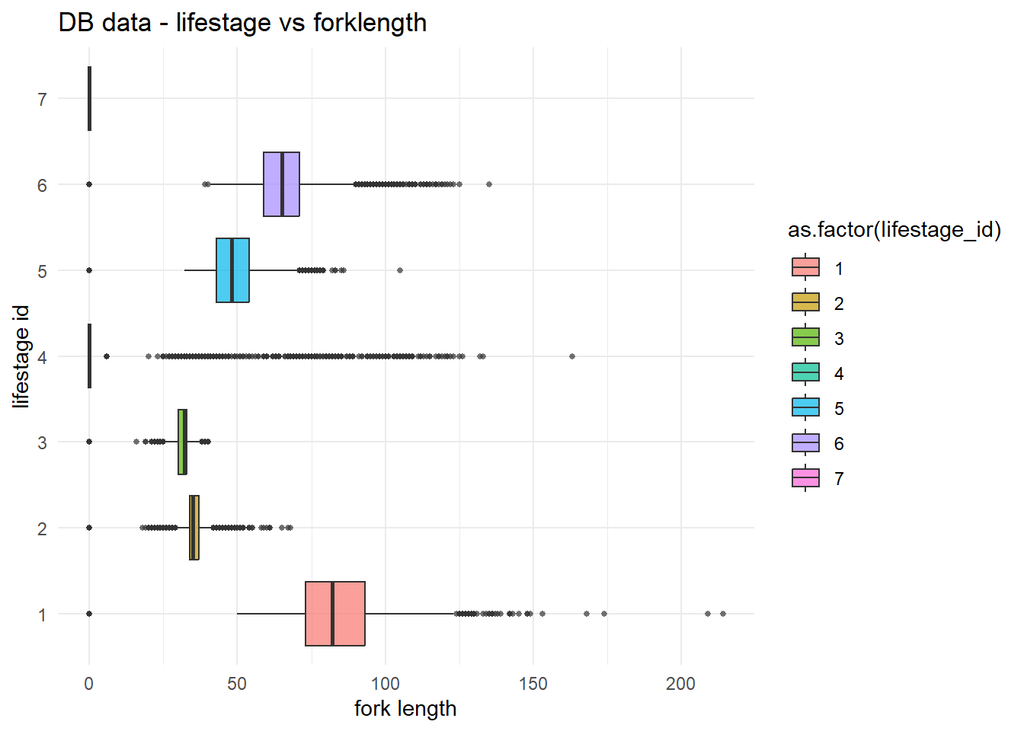

- 0 % of values in the `lifestage_id` column from the EDI data are NA.

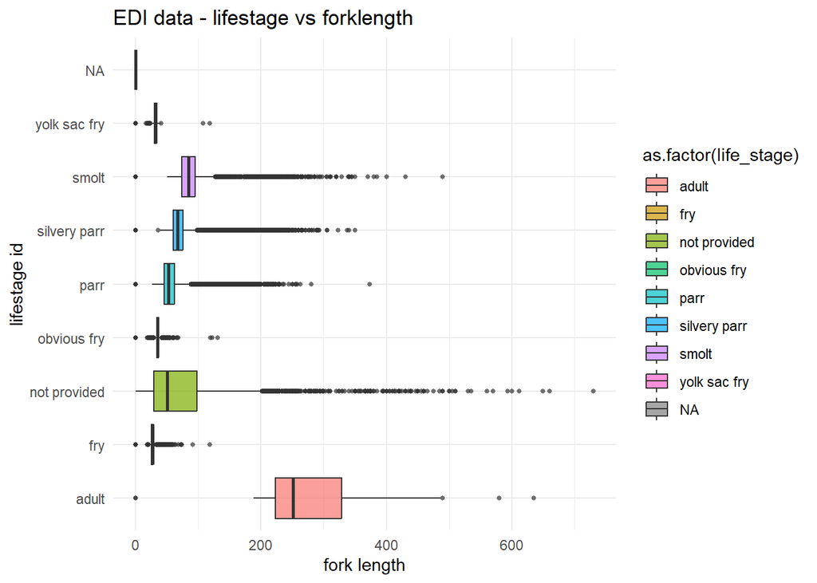

*count*

- 0.1 % of values in the `count` column in edi data are NA.
- 0.1 % of values in the `count` column in database data are NA.

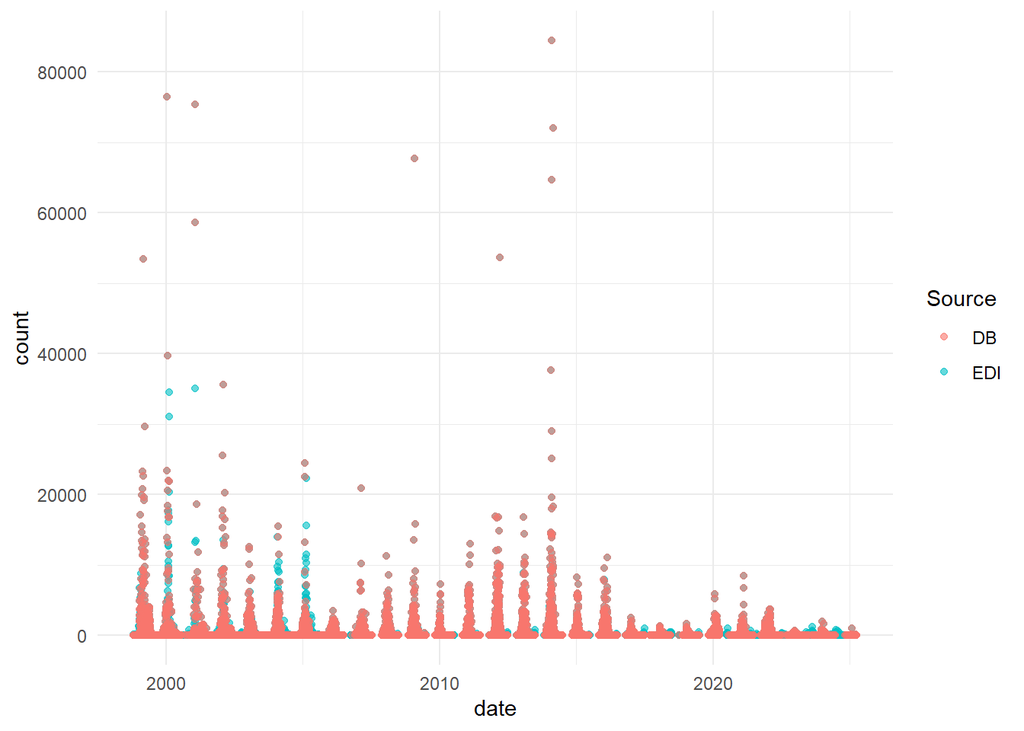

Random pick of data entry to compare between db and EDI

- test 1

```
## Rows: 1
## Columns: 14
## $ id               <int> 44674602
## $ catch_raw_id     <chr> "{511A1464-8C0E-4CBC-83619A1F91634CBC}"
## $ trap_location_id <int> 14
## $ date             <date> 2009-03-13
## $ count            <dbl> 1
## $ run_id           <int> 3
## $ lifestage_id     <int> 2
## $ adipose_clipped  <lgl> FALSE
## $ dead             <lgl> NA
## $ fork_length      <dbl> 0
## $ weight           <dbl> 0
## $ actual_count     <lgl> NA
## $ updated_at       <dttm> 2025-06-03 19:10:04
## $ stream           <chr> "clear creek"
```

```
## Rows: 1
## Columns: 14
## $ catch_row_id <chr> "{511A1464-8C0E-4CBC-83619A1F91634CBC}"
## $ sample_id    <chr> "072_09"
## $ sample_date  <date> 2009-03-13
## $ station_code <chr> "lower clear creek"
## $ count        <dbl> 1
## $ r_catch      <dbl> 1
## $ fork_length  <dbl> 0
## $ weight       <dbl> 0
## $ fws_run      <chr> "fall"
## $ interp       <lgl> FALSE
## $ brood_year   <dbl> 2008
## $ subsample    <chr> NA
## $ common_name  <chr> "Chinook Salmon"
## $ life_stage   <chr> "obvious fry"
```

- test 2

```
## Rows: 1
## Columns: 14
## $ id               <int> 44785413
## $ catch_raw_id     <chr> "{29329E00-E17B-42A0-8049C108CC8CB18D}"
## $ trap_location_id <int> 14
## $ date             <date> 2015-12-21
## $ count            <dbl> 1
## $ run_id           <int> 3
## $ lifestage_id     <int> 2
## $ adipose_clipped  <lgl> FALSE
## $ dead             <lgl> NA
## $ fork_length      <dbl> 31
## $ weight           <dbl> 0
## $ actual_count     <lgl> NA
## $ updated_at       <dttm> 2025-06-03 19:10:04
## $ stream           <chr> "clear creek"
```

```
## Rows: 1
## Columns: 14
## $ catch_row_id <chr> "{29329E00-E17B-42A0-8049C108CC8CB18D}"
## $ sample_id    <chr> "355_15"
## $ sample_date  <date> 2015-12-21
## $ station_code <chr> "lower clear creek"
## $ count        <dbl> 1
## $ r_catch      <dbl> 1
## $ fork_length  <dbl> 31
## $ weight       <dbl> 0
## $ fws_run      <chr> "fall"
## $ interp       <lgl> FALSE
## $ brood_year   <dbl> 2015
## $ subsample    <chr> NA
## $ common_name  <chr> "Chinook Salmon"
## $ life_stage   <chr> "obvious fry"
```

- test 3

```
## Rows: 1
## Columns: 14
## $ id               <int> 45026428
## $ catch_raw_id     <chr> "{2566D65B-9F77-43C7-9F77A072A899FD7D}"
## $ trap_location_id <int> 15
## $ date             <date> 2021-12-02
## $ count            <dbl> 1
## $ run_id           <int> 2
## $ lifestage_id     <int> 2
## $ adipose_clipped  <lgl> FALSE
## $ dead             <lgl> NA
## $ fork_length      <dbl> 33
## $ weight           <dbl> 0
## $ actual_count     <lgl> NA
## $ updated_at       <dttm> 2025-06-03 19:10:04
## $ stream           <chr> "clear creek"
```

```
## Rows: 1
## Columns: 14
## $ catch_row_id <chr> "{2566D65B-9F77-43C7-9F77A072A899FD7D}"
## $ sample_id    <chr> "336_21"
## $ sample_date  <date> 2021-12-02
## $ station_code <chr> "upper clear creek"
## $ count        <dbl> 1
## $ r_catch      <dbl> 1
## $ fork_length  <dbl> 33
## $ weight       <dbl> 0
## $ fws_run      <chr> "spring"
## $ interp       <lgl> FALSE
## $ brood_year   <dbl> 2021
## $ subsample    <chr> "not provided"
## $ common_name  <chr> "Chinook Salmon"
## $ life_stage   <chr> "obvious fry"
```

- test 4

```
## Rows: 1
## Columns: 14
## $ id               <int> 45035172
## $ catch_raw_id     <chr> "{B21666EA-D802-4C28-A3B1372EDD715D97}"
## $ trap_location_id <int> 15
## $ date             <date> 2024-12-09
## $ count            <dbl> 1
## $ run_id           <int> 5
## $ lifestage_id     <int> 3
## $ adipose_clipped  <lgl> FALSE
## $ dead             <lgl> NA
## $ fork_length      <dbl> 32
## $ weight           <dbl> 0
## $ actual_count     <lgl> NA
## $ updated_at       <dttm> 2025-06-03 19:10:04
## $ stream           <chr> "clear creek"
```

```
## Rows: 1
## Columns: 14
## $ catch_row_id <chr> "{B21666EA-D802-4C28-A3B1372EDD715D97}"
## $ sample_id    <chr> "344_24"
## $ sample_date  <date> 2024-12-09
## $ station_code <chr> "upper clear creek"
## $ count        <dbl> 1
## $ r_catch      <dbl> NA
## $ fork_length  <dbl> 32
## $ weight       <dbl> 0
## $ fws_run      <chr> NA
## $ interp       <lgl> FALSE
## $ brood_year   <dbl> NA
## $ subsample    <chr> "not provided"
## $ common_name  <chr> "Chinook Salmon"
## $ life_stage   <chr> "yolk sac fry"
```

#### trap

- Database date range

```
## [1] "1998-08-31 07:50:00 UTC" "2025-04-01 11:29:00 UTC"
```

- EDI date range

```
## [1] "1998-09-01" "2025-04-02"
```

*water_velocity*

Database:

- 0 % of values in the `water_velocity` column are NA.

```
##    Min. 1st Qu.  Median    Mean 3rd Qu.    Max.    NA's
##   0.000   2.060   2.539   3.177   3.332 483.450   27584
```

EDI: * 0 % of values in the `water_velocity` column are NA.

```
##    Min. 1st Qu.  Median    Mean 3rd Qu.    Max.    NA's
##   0.000   2.110   2.620   3.296   3.370 483.450    3662
```

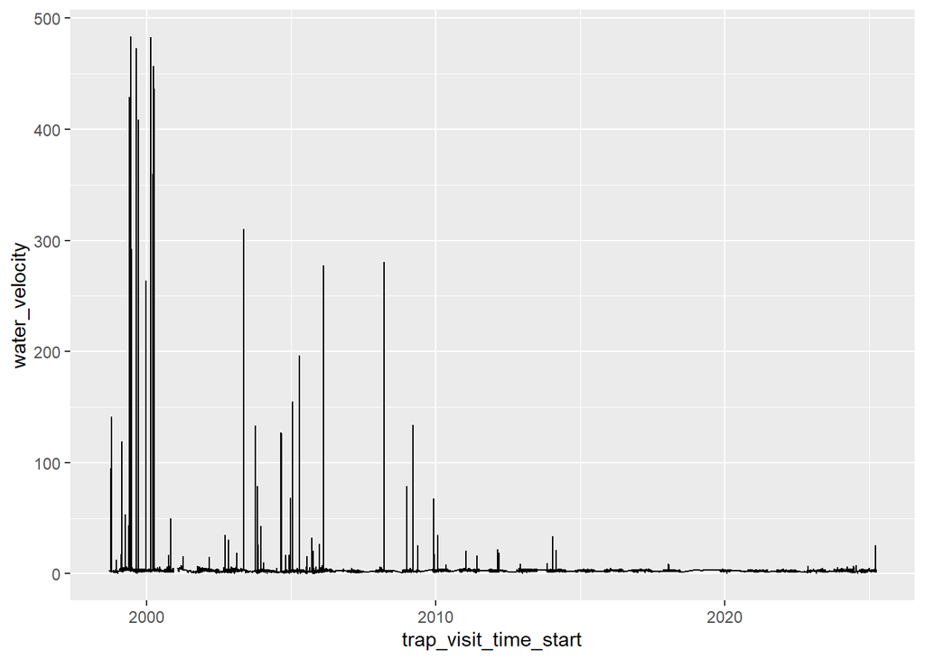

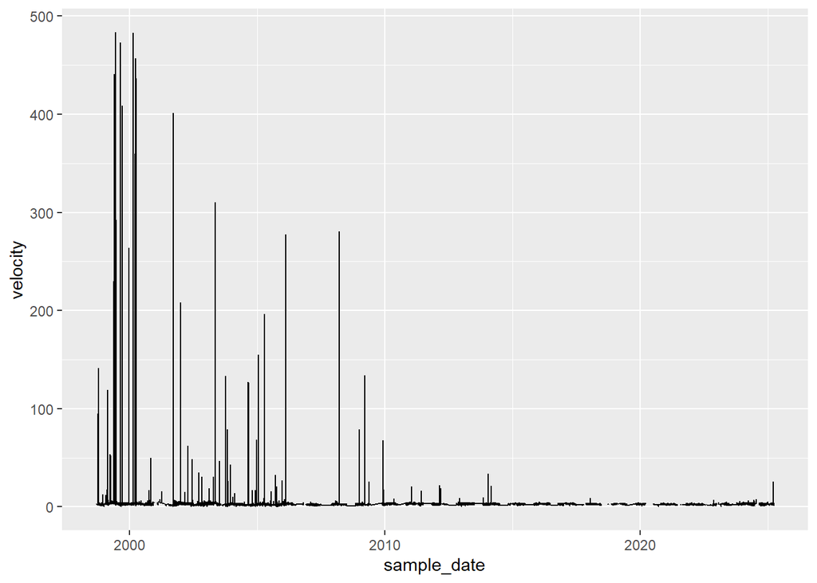

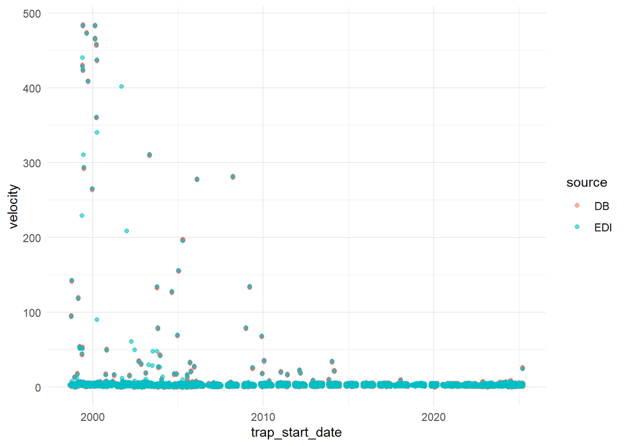

Random pick of data entry to compare between db and EDI

- test 1 (hard to compare because many NAs)

```
## Rows: 1
## Columns: 23
## $ id                         <int> 2093106
## $ trap_location_id           <int> 15
## $ trap_visit_id              <chr> NA
## $ visit_type_id              <int> NA
## $ trap_visit_time_start      <dttm> NA
## $ trap_visit_time_end        <dttm> 2024-08-09 08:00:00
## $ trap_functioning_id        <int> 5
## $ in_half_cone_configuration <lgl> FALSE
## $ fish_processed_id          <int> NA
## $ rpm_start                  <dbl> NA
## $ rpm_end                    <dbl> NA
## $ total_revolutions          <dbl> NA
## $ debris_volume              <dbl> NA
## $ debris_level_id            <int> NA
## $ discharge                  <dbl> NA
## $ water_velocity             <dbl> NA
## $ water_temp                 <dbl> NA
## $ turbidity                  <dbl> NA
## $ include                    <lgl> FALSE
## $ updated_at                 <dttm> 2025-06-09 09:12:16
## $ updated_by                 <chr> "AdminJPE"
## $ stream                     <chr> "clear creek"
## $ source                     <chr> "DB"
```

```
## Rows: 2
## Columns: 31
## $ sample_id          <chr> "222_24", "222_24"
## $ sample_date        <date> 2024-08-09, 2024-08-09
## $ sample_time        <time> 07:32:00, 08:00:00
## $ trap_start_date    <date> 2024-08-08, NA
## $ trap_start_time    <time> 07:58:00,       NA
## $ station_code       <chr> "upper battle creek", "upper clear creek"
## $ depth_adjust       <dbl> 28, NA
## $ avg_time_per_rev   <dbl> 36, NA
## $ flow_start_meter   <dbl> 647000, NA
## $ flow_end_meter     <dbl> 662124, NA
## $ flow_set_time      <dbl> 580, NA
## $ river_left_depth   <dbl> 3.8, NA
## $ river_center_depth <dbl> 3.8, NA
```

[output cut: 18 more lines]

- test 2

```
## Rows: 1
## Columns: 23
## $ id                         <int> 2013985
## $ trap_location_id           <int> 15
## $ trap_visit_id              <chr> NA
## $ visit_type_id              <int> NA
## $ trap_visit_time_start      <dttm> 2013-11-09 12:01:00
## $ trap_visit_time_end        <dttm> 2013-11-10 10:34:00
## $ trap_functioning_id        <int> 3
## $ in_half_cone_configuration <lgl> TRUE
## $ fish_processed_id          <int> NA
## $ rpm_start                  <dbl> 0.3666667
## $ rpm_end                    <dbl> NA
## $ total_revolutions          <dbl> 6289
## $ debris_volume              <dbl> 7
## $ debris_level_id            <int> NA
## $ discharge                  <dbl> 195555
## $ water_velocity             <dbl> 3.67
## $ water_temp                 <dbl> NA
## $ turbidity                  <dbl> 0.74
## $ include                    <lgl> FALSE
## $ updated_at                 <dttm> 2025-06-03 19:15:19
## $ updated_by                 <chr> "AdminJPE"
## $ stream                     <chr> "clear creek"
## $ source                     <chr> "DB"
```

```
## Rows: 1
## Columns: 31
## $ sample_id          <chr> "314_13"
## $ sample_date        <date> 2013-11-10
## $ sample_time        <time> 10:34:00
## $ trap_start_date    <date> 2013-11-09
## $ trap_start_time    <time> 12:01:00
## $ station_code       <chr> "upper clear creek"
## $ depth_adjust       <dbl> 26
## $ avg_time_per_rev   <dbl> 22
## $ flow_start_meter   <dbl> 195555
## $ flow_end_meter     <dbl> 208134
## $ flow_set_time      <dbl> 300
## $ river_left_depth   <dbl> 3.8
## $ river_center_depth <dbl> 3.8
```

[output cut: 18 more lines]

- test 3

```
## Rows: 1
## Columns: 23
## $ id                         <int> 2007291
## $ trap_location_id           <int> 2
## $ trap_visit_id              <chr> NA
## $ visit_type_id              <int> NA
## $ trap_visit_time_start      <dttm> 2003-10-24 12:50:00
## $ trap_visit_time_end        <dttm> 2003-10-25 14:00:00
## $ trap_functioning_id        <int> 2
## $ in_half_cone_configuration <lgl> FALSE
## $ fish_processed_id          <int> NA
## $ rpm_start                  <dbl> 1.4
## $ rpm_end                    <dbl> NA
## $ total_revolutions          <dbl> 2715
## $ debris_volume              <dbl> 21
## $ debris_level_id            <int> NA
## $ discharge                  <dbl> 485600
## $ water_velocity             <dbl> 0.15
## $ water_temp                 <dbl> NA
## $ turbidity                  <dbl> 1.1
## $ include                    <lgl> FALSE
## $ updated_at                 <dttm> 2025-06-03 19:15:19
## $ updated_by                 <chr> "AdminJPE"
## $ stream                     <chr> "battle creek"
## $ source                     <chr> "DB"
```

```
## Rows: 1
## Columns: 31
## $ sample_id          <chr> "298_03"
## $ sample_date        <date> 2003-10-25
## $ sample_time        <time> 14:00:00
## $ trap_start_date    <date> 2003-10-24
## $ trap_start_time    <time> 12:50:00
## $ station_code       <chr> "upper battle creek"
## $ depth_adjust       <dbl> 29
## $ avg_time_per_rev   <dbl> 84
## $ flow_start_meter   <dbl> 485600
## $ flow_end_meter     <dbl> 487981
## $ flow_set_time      <dbl> 1433
## $ river_left_depth   <dbl> NA
## $ river_center_depth <dbl> NA
```

[output cut: 18 more lines]

- test 4

```
## Rows: 1
## Columns: 31
## $ sample_id          <chr> "021_12"
## $ sample_date        <date> 2012-01-21
## $ sample_time        <time> 16:53:00
## $ trap_start_date    <date> 2012-01-20
## $ trap_start_time    <time> 09:11:00
## $ station_code       <chr> "upper clear creek"
## $ depth_adjust       <dbl> 26
## $ avg_time_per_rev   <dbl> 22
## $ flow_start_meter   <dbl> 511600
## $ flow_end_meter     <dbl> 524448
## $ flow_set_time      <dbl> 300
## $ river_left_depth   <dbl> 5.5
## $ river_center_depth <dbl> 5.2
```

[output cut: 18 more lines]

```
## Rows: 8
## Columns: 24
## $ id                         <int> 2012942, 2032450, 2055273, 2082451, 2163985…
## $ trap_location_id           <int> 15, 15, 15, 15, 15, 15, 15, 15
## $ trap_visit_id              <chr> NA, NA, NA, NA, NA, NA, NA, NA
## $ visit_type_id              <int> NA, NA, NA, NA, NA, NA, NA, NA
## $ trap_visit_time_start      <dttm> 2012-01-20 09:11:00, 2012-01-20 09:11:00, 2…
## $ trap_visit_time_end        <dttm> 2012-01-21 16:53:00, 2012-01-21 16:53:00, 2…
## $ trap_functioning_id        <int> 2, 2, 2, 2, 2, 2, 2, 2
## $ in_half_cone_configuration <lgl> TRUE, TRUE, TRUE, TRUE, TRUE, TRUE, TRUE, T…
## $ fish_processed_id          <int> NA, NA, NA, NA, NA, NA, NA, NA
## $ rpm_start                  <dbl> 0.3666667, 0.3666667, 0.3666667, 0.3666667…
## $ rpm_end                    <dbl> NA, NA, NA, NA, NA, NA, NA, NA
## $ total_revolutions          <dbl> 14195, 14195, 14195, 14195, 14195, 14195, …
## $ debris_volume              <dbl> 248, 248, 248, 248, 248, 248, 248, 248
## $ debris_level_id            <int> NA, NA, NA, NA, NA, NA, NA, NA
## $ discharge                  <dbl> 511600, 511600, 511600, 511600, 511600, 511…
## $ water_velocity             <dbl> 3.75, 3.75, 3.75, 3.75, 3.75, 3.75, 3.75, 3…
## $ water_temp                 <dbl> NA, NA, NA, NA, NA, NA, NA, NA
## $ turbidity                  <dbl> 6.07, 6.07, 6.07, 6.07, 6.07, 6.07, 6.07, 6…
## $ include                    <lgl> FALSE, FALSE, FALSE, FALSE, FALSE, FALSE, F…
## $ updated_at                 <dttm> 2025-06-03 19:15:19, 2025-06-03 19:52:06, 2…
## $ updated_by                 <chr> "AdminJPE", "AdminJPE", "AdminJPE", "AdminJ…
## $ stream                     <chr> "clear creek", "clear creek", "clear creek"…
## $ date                       <date> 2012-01-20, 2012-01-20, 2012-01-20, 2012-01…
## $ source                     <chr> "EDI", "EDI", "EDI", "EDI", "EDI", "EDI", "…
```

#### release

**Findings:**

- date range is the same
- fork length values seem the same as well
- random checks are consistent

DB glimpse

```
## Rows: 854
## Columns: 12
## $ id                          <int> 61315, 61316, 61317, 61318, 61319, 61320, …
## $ trap_location_id            <int> 14, 14, 14, 2, 2, 14, 14, 14, 2, 2, 14, 14…
## $ release_id                  <chr> "CLR494", "CLR493", "CLR497", "BAT264", "B…
## $ date_released               <dttm> 2011-01-08, 2011-01-08, 2011-01-12, 2011-…
## $ run_id                      <int> 6, 6, 6, 6, 6, 6, 6, 6, 6, 6, 6, 6, 6, 6, …
## $ median_fork_length_released <dbl> 35, 36, 37, 37, 37, 37, 37, 37, 37, 38, 37…
## $ lifestage_id                <int> NA, NA, NA, NA, NA, NA, NA, NA, NA, NA, NA…
## $ origin_id                   <int> 3, 3, 3, 3, 3, 3, 3, 3, 1, 3, 3, 3, 3, 1, …
## $ number_released             <dbl> 153, 153, 299, 518, 500, 296, 300, 299, 24…
## $ updated_at                  <dttm> 2025-06-03 19:15:43, 2025-06-03 19:15:43,…
## $ updated_by                  <chr> "AdminJPE", "AdminJPE", "AdminJPE", "Admin…
## $ stream                      <chr> "clear creek", "clear creek", "clear creek…
```

- Database date range (`date_released`)

```
## [1] "2003-12-03 UTC" "2025-01-29 UTC"
```

EDI glimpse

```
## Rows: 854
## Columns: 13
## $ release_id                  <chr> "CLR171", "CLR172", "CLR173", "CLR174", "C…
## $ date_released               <date> 2003-12-03, 2003-12-03, 2003-12-13, 2003-…
## $ time_released               <time> 16:12:00, 16:12:00, 15:13:00, 15:13:00, 1…
## $ release_site                <chr> "vulture bar", "clear creek road bridge", …
## $ site                        <chr> "lower clear creek", "upper clear creek", …
## $ number_released             <dbl> 14, 20, 259, 259, 105, 60, 241, 409, 248, …
## $ median_fork_length_released <dbl> 34.0, 33.5, 35.0, 35.0, 35.0, 33.0, 35.0, …
## $ days_held_post_mark         <dbl> 0, 0, 0, 0, 0, 0, 0, 0, 1, 1, 1, 1, 1, 1, …
## $ day_or_night_release        <chr> "night", "night", "night", "day", "night",…
## $ release_temp                <dbl> 51.300, 49.590, 49.100, 48.760, 48.200, 47…
## $ release_flow                <dbl> 227, 227, 333, 333, 252, 252, 238, 241, 32…
## $ release_turbidity           <dbl> NA, NA, NA, NA, NA, NA, NA, NA, NA, NA, NA…
## $ origin_released             <chr> NA, NA, NA, NA, NA, NA, NA, NA, NA, NA, NA…
```

- EDI date range (`date_released`)

```
## [1] "2003-12-03" "2025-01-29"
```

*median_fork_length_released*

EDI:

- 2 % of values in the `median_fork_length_released` column are NA.

```
##    Min. 1st Qu.  Median    Mean 3rd Qu.    Max.    NA's
##    0.00   36.00   37.00   38.32   38.00   78.00      17
```

DB:

- 2 % of values in the `median_fork_length_released` column are NA.

```
##    Min. 1st Qu.  Median    Mean 3rd Qu.    Max.    NA's
##    0.00   36.00   37.00   38.32   38.00   78.00      17
```

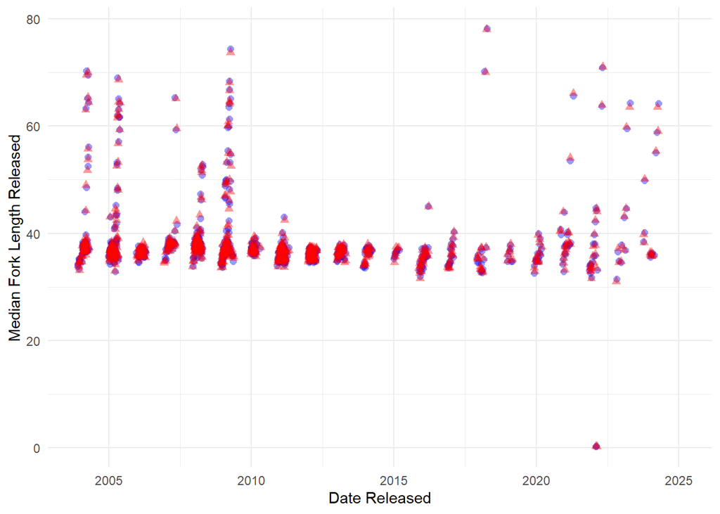

Random pick of data entry to compare between db and EDI

- test 1

```
## Rows: 1
## Columns: 13
## $ id                          <int> 61520
## $ trap_location_id            <int> 14
## $ release_id                  <chr> "CLR637"
## $ date_released               <dttm> 2015-03-03
## $ run_id                      <int> 6
## $ median_fork_length_released <dbl> 37
## $ lifestage_id                <int> NA
## $ origin_id                   <int> 3
## $ number_released             <dbl> 390
## $ updated_at                  <dttm> 2025-06-03 19:15:43
## $ updated_by                  <chr> "AdminJPE"
## $ stream                      <chr> "clear creek"
## $ source                      <chr> "DB"
```

```
## Rows: 1
## Columns: 14
## $ release_id                  <chr> "CLR637"
## $ date_released               <date> 2015-03-03
## $ time_released               <time> 18:10:00
## $ release_site                <chr> "vulture bar"
## $ site                        <chr> "lower clear creek"
## $ number_released             <dbl> 390
## $ median_fork_length_released <dbl> 37
## $ days_held_post_mark         <dbl> 1
## $ day_or_night_release        <chr> "night"
## $ release_temp                <dbl> 52.2
## $ release_flow                <dbl> 227
## $ release_turbidity           <dbl> 1.67
## $ origin_released             <chr> NA
## $ source                      <chr> "EDI"
```

- test 2

```
## Rows: 1
## Columns: 13
## $ id                          <int> 61137
## $ trap_location_id            <int> 2
## $ release_id                  <chr> "BAT187"
## $ date_released               <dttm> 2008-03-15
## $ run_id                      <int> 6
## $ median_fork_length_released <dbl> 37
## $ lifestage_id                <int> NA
## $ origin_id                   <int> 1
## $ number_released             <dbl> 304
## $ updated_at                  <dttm> 2025-06-03 19:15:43
## $ updated_by                  <chr> "AdminJPE"
## $ stream                      <chr> "battle creek"
## $ source                      <chr> "DB"
```

```
## Rows: 1
## Columns: 14
## $ release_id                  <chr> "BAT187"
## $ date_released               <date> 2008-03-15
## $ time_released               <time> 19:55:00
## $ release_site                <chr> NA
## $ site                        <chr> "upper battle creek"
## $ number_released             <dbl> 304
## $ median_fork_length_released <dbl> 37
## $ days_held_post_mark         <dbl> 1
## $ day_or_night_release        <chr> "night"
## $ release_temp                <dbl> 50.2
## $ release_flow                <dbl> 423
## $ release_turbidity           <dbl> NA
## $ origin_released             <chr> "natural"
## $ source                      <chr> "EDI"
```

- test 4

```
## Rows: 1
## Columns: 13
## $ id                          <int> 61317
## $ trap_location_id            <int> 14
## $ release_id                  <chr> "CLR497"
## $ date_released               <dttm> 2011-01-12
## $ run_id                      <int> 6
## $ median_fork_length_released <dbl> 37
## $ lifestage_id                <int> NA
## $ origin_id                   <int> 3
## $ number_released             <dbl> 299
## $ updated_at                  <dttm> 2025-06-03 19:15:43
## $ updated_by                  <chr> "AdminJPE"
## $ stream                      <chr> "clear creek"
## $ source                      <chr> "DB"
```

```
## Rows: 1
## Columns: 14
## $ release_id                  <chr> "CLR497"
## $ date_released               <date> 2011-01-12
## $ time_released               <time> 18:10:00
## $ release_site                <chr> "vulture bar"
## $ site                        <chr> "lower clear creek"
## $ number_released             <dbl> 299
## $ median_fork_length_released <dbl> 37
## $ days_held_post_mark         <dbl> 1
## $ day_or_night_release        <chr> "night"
## $ release_temp                <dbl> 46.4
## $ release_flow                <dbl> 265
## $ release_turbidity           <dbl> NA
## $ origin_released             <chr> NA
## $ source                      <chr> "EDI"
```

#### recapture (recapture_fish)

**Findings:**

Database glimpse:

```
## Rows: 34,160
## Columns: 14
## $ id               <int> 234566, 234567, 234568, 234569, 234570, 234571, 23457…
## $ trap_location_id <int> 14, 15, 15, 14, 15, 14, 15, 14, 14, 15, 15, 14, 15, 1…
## $ catch_raw_id     <int> NA, NA, NA, NA, NA, NA, NA, NA, NA, NA, NA, NA, NA, N…
## $ date             <date> 2003-12-04, 2003-12-04, 2003-12-05, 2003-12-05, 2003…
## $ count            <dbl> 3, 6, 0, 0, 0, 0, 0, 0, 0, 0, 6, 5, 1, 0, 0, 0, 0, 0,…
## $ run_id           <int> NA, NA, NA, NA, NA, NA, NA, NA, NA, NA, NA, NA, NA, N…
## $ lifestage_id     <int> NA, NA, NA, NA, NA, NA, NA, NA, NA, NA, NA, NA, NA, N…
## $ adipose_clipped  <lgl> NA, NA, NA, NA, NA, NA, NA, NA, NA, NA, NA, NA, NA, N…
## $ dead             <lgl> NA, NA, NA, NA, NA, NA, NA, NA, NA, NA, NA, NA, NA, N…
## $ fork_length      <dbl> 34.0, 33.5, NA, NA, NA, NA, NA, NA, NA, NA, 35.0, 35.…
## $ weight           <dbl> NA, NA, NA, NA, NA, NA, NA, NA, NA, NA, NA, NA, NA, N…
## $ release_id       <chr> "CLR171", "CLR172", "CLR172", "CLR171", "CLR172", "CL…
## $ updated_at       <dttm> 2025-06-03 19:15:37, 2025-06-03 19:15:37, 2025-06-03…
## $ stream           <chr> "clear creek", "clear creek", "clear creek", "clear c…
```

- Database date range (`recaptured_fish`)

```
## [1] "2003-12-04" "2025-02-03"
```

EDI glimpse:

```
## Rows: 4,270
## Columns: 6
## $ release_id                    <chr> "CLR171", "CLR171", "CLR171", "CLR171", …
## $ date_recaptured               <date> 2003-12-04, 2003-12-05, 2003-12-06, 200…
## $ release_site                  <chr> "vulture bar", "vulture bar", "vulture b…
## $ site                          <chr> "lower clear creek", "lower clear creek"…
## $ number_recaptured             <dbl> 3, 0, 0, 0, 0, 6, 0, 0, 0, 0, 5, 0, 0, 0…
## $ median_fork_length_recaptured <dbl> 34.0, NA, NA, NA, NA, 33.5, NA, NA, NA, …
```

- EDI date range (`date_recaptured`)

```
## [1] "2003-12-04" "2025-02-03"
```

*date vs count/number_recapture*

- 2.1 % of values in the `count` column from the database are NA.
- 2.1 % of values in the `number_recaptured` column from EDI are NA.

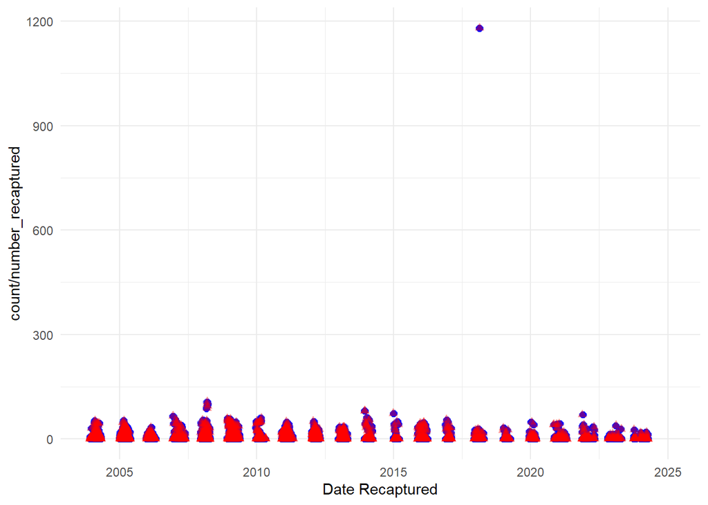

*date vs fork_length*

- 66 % of values in the `fork_length` column from the database are NA.
- 66 % of values in the `median_fork_length_recaptured` column from EDI are NA.

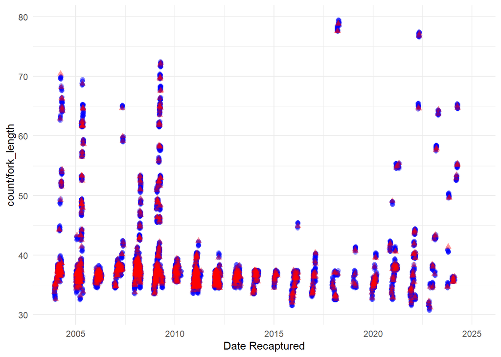

Random pick of data entry to compare between db and EDI

- test 1

```
## Rows: 8
## Columns: 15
## $ id               <int> 234826, 239096, 244481, 249923, 255365, 260807, 26624…
## $ trap_location_id <int> 15, 15, 15, 15, 15, 15, 15, 15
## $ catch_raw_id     <int> NA, NA, NA, NA, NA, NA, NA, NA
## $ date             <date> 2004-04-13, 2004-04-13, 2004-04-13, 2004-04-13, 2004-…
## $ count            <dbl> 0, 0, 0, 0, 0, 0, 0, 0
## $ run_id           <int> NA, NA, NA, NA, NA, NA, NA, NA
## $ lifestage_id     <int> NA, NA, NA, NA, NA, NA, NA, NA
## $ adipose_clipped  <lgl> NA, NA, NA, NA, NA, NA, NA, NA
## $ dead             <lgl> NA, NA, NA, NA, NA, NA, NA, NA
## $ fork_length      <dbl> NA, NA, NA, NA, NA, NA, NA, NA
## $ weight           <dbl> NA, NA, NA, NA, NA, NA, NA, NA
## $ release_id       <chr> "CLR210", "CLR210", "CLR210", "CLR210", "CLR210", "CL…
## $ updated_at       <dttm> 2025-06-03 19:15:37, 2025-06-03 19:52:25, 2025-06-09…
## $ stream           <chr> "clear creek", "clear creek", "clear creek", "clear c…
## $ source           <chr> "DB", "DB", "DB", "DB", "DB", "DB", "DB", "DB"
```

```
## Rows: 1
## Columns: 7
## $ release_id                    <chr> "CLR210"
## $ date_recaptured               <date> 2004-04-13
## $ release_site                  <chr> "clear creek road bridge"
## $ site                          <chr> "upper clear creek"
## $ number_recaptured             <dbl> 0
## $ median_fork_length_recaptured <dbl> NA
## $ source                        <chr> "EDI"
```

- test 2

```
## Rows: 1
## Columns: 7
## $ release_id                    <chr> "CLR386"
## $ date_recaptured               <date> 2008-03-02
## $ release_site                  <chr> "vulture bar"
## $ site                          <chr> "lower clear creek"
## $ number_recaptured             <dbl> 12
## $ median_fork_length_recaptured <dbl> 37
## $ source                        <chr> "EDI"
```

```
## Rows: 8
## Columns: 15
## $ id               <int> 236052, 240322, 245707, 251149, 256591, 262033, 26747…
## $ trap_location_id <int> 14, 14, 14, 14, 14, 14, 14, 14
## $ catch_raw_id     <int> NA, NA, NA, NA, NA, NA, NA, NA
## $ date             <date> 2008-03-02, 2008-03-02, 2008-03-02, 2008-03-02, 2008-…
## $ count            <dbl> 12, 12, 12, 12, 12, 12, 12, 12
## $ run_id           <int> NA, NA, NA, NA, NA, NA, NA, NA
## $ lifestage_id     <int> NA, NA, NA, NA, NA, NA, NA, NA
## $ adipose_clipped  <lgl> NA, NA, NA, NA, NA, NA, NA, NA
## $ dead             <lgl> NA, NA, NA, NA, NA, NA, NA, NA
## $ fork_length      <dbl> 37, 37, 37, 37, 37, 37, 37, 37
## $ weight           <dbl> NA, NA, NA, NA, NA, NA, NA, NA
## $ release_id       <chr> "CLR386", "CLR386", "CLR386", "CLR386", "CLR386", "CL…
## $ updated_at       <dttm> 2025-06-03 19:15:37, 2025-06-03 19:52:25, 2025-06-09…
## $ stream           <chr> "clear creek", "clear creek", "clear creek", "clear c…
## $ source           <chr> "DB", "DB", "DB", "DB", "DB", "DB", "DB", "DB"
```

- test 3

```
## Rows: 1
## Columns: 7
## $ release_id                    <chr> "CLR677"
## $ date_recaptured               <date> 2017-01-31
## $ release_site                  <chr> "vulture bar"
## $ site                          <chr> "lower clear creek"
## $ number_recaptured             <dbl> 0
## $ median_fork_length_recaptured <dbl> NA
## $ source                        <chr> "EDI"
```

```
## Rows: 8
## Columns: 15
## $ id               <int> 238276, 242546, 247931, 253373, 258815, 264257, 26969…
## $ trap_location_id <int> 14, 14, 14, 14, 14, 14, 14, 14
## $ catch_raw_id     <int> NA, NA, NA, NA, NA, NA, NA, NA
## $ date             <date> 2017-01-31, 2017-01-31, 2017-01-31, 2017-01-31, 2017-…
## $ count            <dbl> 0, 0, 0, 0, 0, 0, 0, 0
## $ run_id           <int> NA, NA, NA, NA, NA, NA, NA, NA
## $ lifestage_id     <int> NA, NA, NA, NA, NA, NA, NA, NA
## $ adipose_clipped  <lgl> NA, NA, NA, NA, NA, NA, NA, NA
## $ dead             <lgl> NA, NA, NA, NA, NA, NA, NA, NA
## $ fork_length      <dbl> NA, NA, NA, NA, NA, NA, NA, NA
## $ weight           <dbl> NA, NA, NA, NA, NA, NA, NA, NA
## $ release_id       <chr> "CLR677", "CLR677", "CLR677", "CLR677", "CLR677", "CL…
## $ updated_at       <dttm> 2025-06-03 19:15:37, 2025-06-03 19:52:25, 2025-06-09…
## $ stream           <chr> "clear creek", "clear creek", "clear creek", "clear c…
## $ source           <chr> "DB", "DB", "DB", "DB", "DB", "DB", "DB", "DB"
```

- test 4

```
## Rows: 1
## Columns: 7
## $ release_id                    <chr> "BAT371"
## $ date_recaptured               <date> 2024-04-03
## $ release_site                  <chr> NA
## $ site                          <chr> "upper battle creek"
## $ number_recaptured             <dbl> 13
## $ median_fork_length_recaptured <dbl> 65
## $ source                        <chr> "EDI"
```

```
## Rows: 8
## Columns: 15
## $ id               <int> 238796, 243066, 248451, 253893, 259335, 264777, 27021…
## $ trap_location_id <int> 2, 2, 2, 2, 2, 2, 2, 2
## $ catch_raw_id     <int> NA, NA, NA, NA, NA, NA, NA, NA
## $ date             <date> 2024-04-03, 2024-04-03, 2024-04-03, 2024-04-03, 2024-…
## $ count            <dbl> 13, 13, 13, 13, 13, 13, 13, 13
## $ run_id           <int> NA, NA, NA, NA, NA, NA, NA, NA
## $ lifestage_id     <int> NA, NA, NA, NA, NA, NA, NA, NA
## $ adipose_clipped  <lgl> NA, NA, NA, NA, NA, NA, NA, NA
## $ dead             <lgl> NA, NA, NA, NA, NA, NA, NA, NA
## $ fork_length      <dbl> 65, 65, 65, 65, 65, 65, 65, 65
## $ weight           <dbl> NA, NA, NA, NA, NA, NA, NA, NA
## $ release_id       <chr> "BAT371", "BAT371", "BAT371", "BAT371", "BAT371", "BA…
## $ updated_at       <dttm> 2025-06-03 19:15:37, 2025-06-03 19:52:25, 2025-06-09…
## $ stream           <chr> "battle creek", "battle creek", "battle creek", "batt…
## $ source           <chr> "DB", "DB", "DB", "DB", "DB", "DB", "DB", "DB"
```

### Butte

#### catch

**- Findings catch:** - date range is different, will filter EDI to start 1999 for this data comparison purpose - It seems like the database only has a few data entires from 1999, 2017 and 2020. Then it jumps to 2022 onwards - lifestage on EDI data are repetitive (e.g. Parr vs parr, Smolt va smolt) - test 2: catch_raw_id == “15924” was not found in Data (called catchRawID on EDI) - test 4: date of 2022-02-22 does not match any data entries on database (there seems to be a gap between 1999 and 2022, check if this is expected)

- DB date range

```
## [1] "1999-06-05" "2025-04-20"
```

- EDI date range (`visitTime`)

```
## Rows: 114,501
## Columns: 17
## $ ProjectDescriptionID <dbl> NA, NA, NA, NA, NA, NA, NA, NA, NA, NA, NA, NA, N…
## $ catchRawID           <dbl> NA, NA, NA, NA, NA, NA, NA, NA, NA, NA, NA, NA, N…
## $ trapVisitID          <dbl> NA, NA, NA, NA, NA, NA, NA, NA, NA, NA, NA, NA, N…
## $ commonName           <chr> "chinook salmon", "chinook salmon", "chinook salm…
## $ releaseID            <dbl> NA, NA, NA, NA, NA, NA, NA, NA, NA, NA, NA, NA, N…
## $ atCaptureRun         <chr> "spring", "spring", "spring", "spring", "spring",…
## $ fishOrigin           <chr> NA, NA, NA, NA, NA, NA, NA, NA, NA, NA, NA, NA, N…
## $ lifeStage            <chr> "not recorded", "not recorded", "not recorded", "…
## $ forkLength           <dbl> 33, 34, 34, 35, 36, 118, 130, 132, 34, 35, NA, 33…
## $ totalLength          <dbl> NA, NA, NA, NA, NA, NA, NA, NA, NA, NA, NA, NA, N…
## $ n                    <dbl> 1, 1, 1, 1, 1, 1, 1, 1, 1, 1, 1, 4, 4, 1, 2, 14, …
## $ visitTime            <dttm> 1995-12-01 12:00:00, 1995-12-01 12:00:00, 1995-1…
## $ visitType            <chr> NA, NA, NA, NA, NA, NA, NA, NA, NA, NA, NA, NA, N…
## $ siteName             <chr> "parrot-phelan", "parrot-phelan", "parrot-phelan"…
## $ subSiteName          <chr> "pp rst", "pp rst", "pp rst", "pp rst", "pp rst",…
## $ finalRun             <chr> NA, NA, NA, NA, NA, NA, NA, NA, NA, NA, NA, NA, N…
## $ actualCount          <chr> NA, NA, NA, NA, NA, NA, NA, NA, NA, NA, NA, NA, N…
```

```
## [1] "1995-12-01 12:00:00 UTC" "2025-04-21 00:00:00 UTC"
```

*forkLength*

EDI

- 23.3 % of values in the `forkLength` column are NA.

```
##    Min. 1st Qu.  Median    Mean 3rd Qu.    Max.    NA's
##     0.0    36.0    47.0    54.8    67.0  1035.0   26680
```

DB

- 6.6 % of values in the `fork_length` column are NA.

```
##    Min. 1st Qu.  Median    Mean 3rd Qu.    Max.    NA's
##    0.00   35.00   36.00   40.24   38.00  510.00     749
```

exploration plots

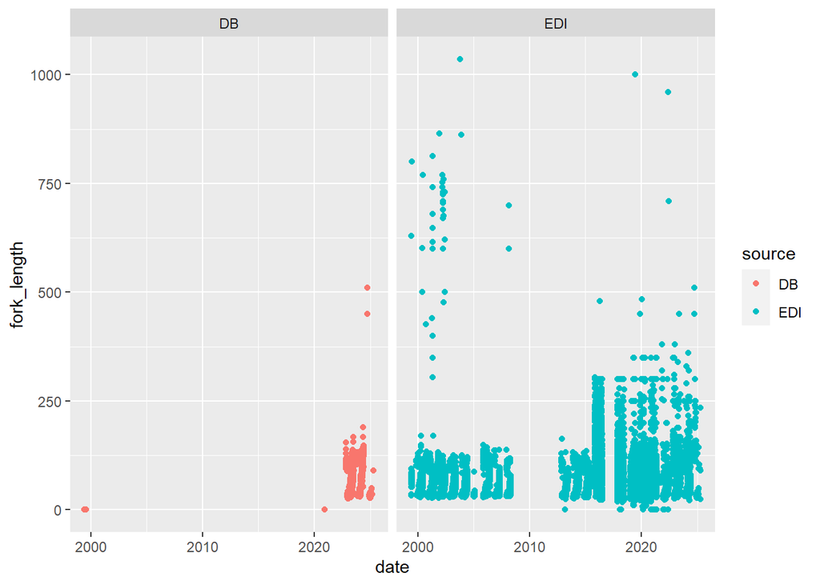

- 0 % of values in the `lifestage_id` column from the database are NA.

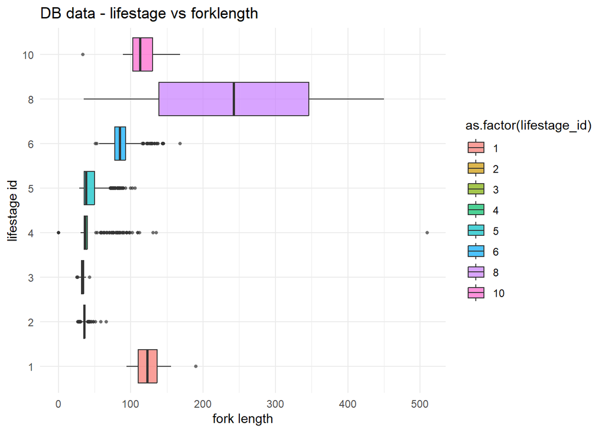

- 0 % of values in the `lifeStage` column from the EDI data are NA.

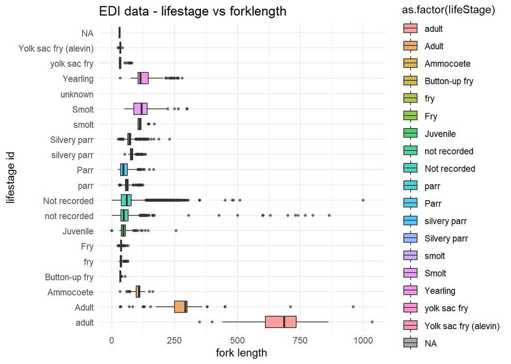

*count*

- 0 % of values in the `n` column in edi data are NA.

```
##      Min.   1st Qu.    Median      Mean   3rd Qu.      Max.
##      0.00      1.00      1.00     42.74      2.00 220000.00
```

- 0 % of values in the `count` column in database data are NA.

```
##    Min. 1st Qu.  Median    Mean 3rd Qu.    Max.
##    0.00    1.00    1.00    3.35    1.00 2043.00
```

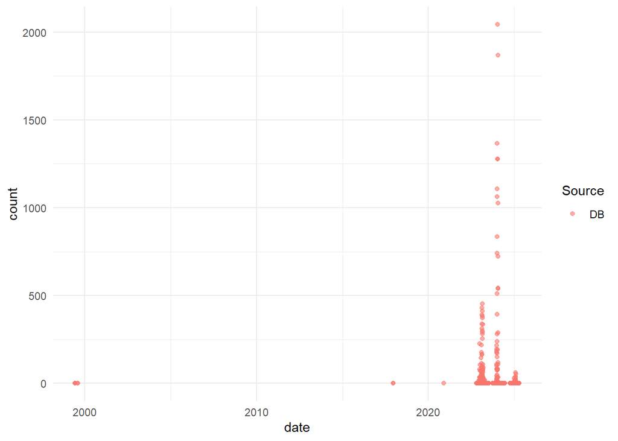

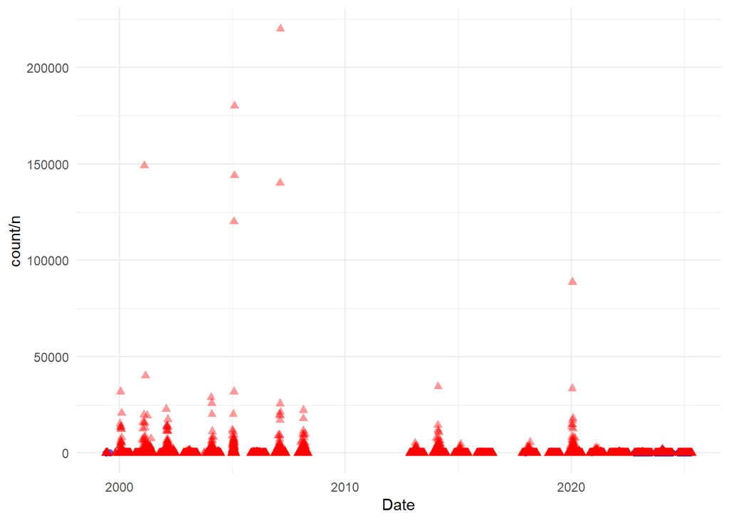

Random pick of data entry to compare between db and EDI

- test 1

```
## Rows: 1
## Columns: 15
## $ id               <int> 45936875
## $ catch_raw_id     <chr> "55171"
## $ trap_location_id <int> 8
## $ date             <date> 2024-01-04
## $ count            <dbl> 1
## $ run_id           <int> 5
## $ lifestage_id     <int> 2
## $ adipose_clipped  <lgl> FALSE
## $ dead             <lgl> TRUE
## $ fork_length      <dbl> 36
## $ weight           <dbl> NA
## $ actual_count     <lgl> TRUE
## $ updated_at       <dttm> 2025-06-09 09:05:05
## $ stream           <chr> "butte creek"
## $ source           <chr> "DB"
```

```
## Rows: 1
## Columns: 18
## $ ProjectDescriptionID <dbl> 11
## $ catchRawID           <dbl> 55171
## $ trapVisitID          <dbl> 2743
## $ commonName           <chr> "Chinook salmon"
## $ releaseID            <dbl> 0
## $ atCaptureRun         <chr> "Spring"
## $ fishOrigin           <chr> "Natural"
## $ lifeStage            <chr> "Fry"
## $ forkLength           <dbl> 36
## $ totalLength          <dbl> NA
## $ n                    <dbl> 1
## $ visitTime            <dttm> 2024-01-04
## $ visitType            <chr> "Continue trapping"
## $ siteName             <chr> "Parrott-Phelan canal trap box"
## $ subSiteName          <chr> "canal trap box"
## $ finalRun             <chr> NA
## $ actualCount          <chr> "Yes"
## $ source               <chr> "EDI"
```

- test 2

```
## Rows: 1
## Columns: 18
## $ ProjectDescriptionID <dbl> 11
## $ catchRawID           <dbl> 15924
## $ trapVisitID          <dbl> 997
## $ commonName           <chr> "Chinook salmon"
## $ releaseID            <dbl> 255
## $ atCaptureRun         <chr> "Not recorded"
## $ fishOrigin           <chr> "Natural"
## $ lifeStage            <chr> "Not recorded"
## $ forkLength           <dbl> 45
## $ totalLength          <dbl> NA
## $ n                    <dbl> 1
## $ visitTime            <dttm> 2020-03-12
## $ visitType            <chr> "Continue trapping"
## $ siteName             <chr> "Parrott-Phelan canal trap box"
## $ subSiteName          <chr> "canal trap box"
## $ finalRun             <chr> NA
## $ actualCount          <chr> "Yes"
## $ source               <chr> "EDI"
```

```
## Rows: 0
## Columns: 15
## $ id               <int>
## $ catch_raw_id     <chr>
## $ trap_location_id <int>
## $ date             <date>
## $ count            <dbl>
## $ run_id           <int>
## $ lifestage_id     <int>
## $ adipose_clipped  <lgl>
## $ dead             <lgl>
## $ fork_length      <dbl>
## $ weight           <dbl>
## $ actual_count     <lgl>
## $ updated_at       <dttm>
## $ stream           <chr>
## $ source           <chr>
```

- test 2

```
## Rows: 1
## Columns: 15
## $ id               <int> 45942470
## $ catch_raw_id     <chr> "51525"
## $ trap_location_id <int> 6
## $ date             <date> 2023-05-24
## $ count            <dbl> 1
## $ run_id           <int> 5
## $ lifestage_id     <int> 6
## $ adipose_clipped  <lgl> FALSE
## $ dead             <lgl> TRUE
## $ fork_length      <dbl> 85
## $ weight           <dbl> NA
## $ actual_count     <lgl> TRUE
## $ updated_at       <dttm> 2025-06-09 09:05:05
## $ stream           <chr> "butte creek"
## $ source           <chr> "DB"
```

```
## Rows: 1
## Columns: 18
## $ ProjectDescriptionID <dbl> 11
## $ catchRawID           <dbl> 51525
## $ trapVisitID          <dbl> 2462
## $ commonName           <chr> "Chinook salmon"
## $ releaseID            <dbl> 0
## $ atCaptureRun         <chr> "Spring"
## $ fishOrigin           <chr> "Natural"
## $ lifeStage            <chr> "Silvery parr"
## $ forkLength           <dbl> 85
## $ totalLength          <dbl> NA
## $ n                    <dbl> 1
## $ visitTime            <dttm> 2023-05-24
## $ visitType            <chr> "Continue trapping"
## $ siteName             <chr> "Parrot-Phelan RST"
## $ subSiteName          <chr> "PP RST"
## $ finalRun             <chr> NA
## $ actualCount          <chr> "Yes"
## $ source               <chr> "EDI"
```

- test 3

```
## Rows: 1
## Columns: 15
## $ id               <int> 45937576
## $ catch_raw_id     <chr> "60956"
## $ trap_location_id <int> 8
## $ date             <date> 2024-12-28
## $ count            <dbl> 1
## $ run_id           <int> 5
## $ lifestage_id     <int> 2
## $ adipose_clipped  <lgl> FALSE
## $ dead             <lgl> TRUE
## $ fork_length      <dbl> 35
## $ weight           <dbl> NA
## $ actual_count     <lgl> TRUE
## $ updated_at       <dttm> 2025-06-09 09:05:05
## $ stream           <chr> "butte creek"
## $ source           <chr> "DB"
```

```
## Rows: 1
## Columns: 18
## $ ProjectDescriptionID <dbl> 11
## $ catchRawID           <dbl> 60956
## $ trapVisitID          <dbl> 3214
## $ commonName           <chr> "Chinook salmon"
## $ releaseID            <dbl> 255
## $ atCaptureRun         <chr> "Spring"
## $ fishOrigin           <chr> "Natural"
## $ lifeStage            <chr> "Fry"
## $ forkLength           <dbl> 35
## $ totalLength          <dbl> NA
## $ n                    <dbl> 1
## $ visitTime            <dttm> 2024-12-28
## $ visitType            <chr> "Continue trapping"
## $ siteName             <chr> "Parrott-Phelan canal trap box"
## $ subSiteName          <chr> "canal trap box"
## $ finalRun             <chr> NA
## $ actualCount          <chr> "Yes"
## $ source               <chr> "EDI"
```

- test 4

```
## Rows: 1
## Columns: 18
## $ ProjectDescriptionID <dbl> 11
## $ catchRawID           <dbl> 33534
## $ trapVisitID          <dbl> 1808
## $ commonName           <chr> "Chinook salmon"
## $ releaseID            <dbl> 0
## $ atCaptureRun         <chr> "Spring"
## $ fishOrigin           <chr> "Natural"
## $ lifeStage            <chr> "Parr"
## $ forkLength           <dbl> 33
## $ totalLength          <dbl> NA
## $ n                    <dbl> 1
## $ visitTime            <dttm> 2022-02-22
## $ visitType            <chr> "Continue trapping"
## $ siteName             <chr> "Parrot-Phelan RST"
## $ subSiteName          <chr> "PP RST"
## $ finalRun             <chr> NA
## $ actualCount          <chr> "Yes"
## $ source               <chr> "EDI"
```

```
## Rows: 0
## Columns: 15
## $ id               <int>
## $ catch_raw_id     <chr>
## $ trap_location_id <int>
## $ date             <date>
## $ count            <dbl>
## $ run_id           <int>
## $ lifestage_id     <int>
## $ adipose_clipped  <lgl>
## $ dead             <lgl>
## $ fork_length      <dbl>
## $ weight           <dbl>
## $ actual_count     <lgl>
## $ updated_at       <dttm>
## $ stream           <chr>
## $ source           <chr>
```

#### trap

**- Findings:** - time ranges are different, database has 2020 data only (wondering if this is an error?) - couldn’t do random test checks since couldn’t find field in common

- Database glimpse

```
## Rows: 1,318
## Columns: 22
## $ id                         <int> 2023627, 2023634, 2023641, 2043135, 2043142…
## $ trap_location_id           <int> 74, 74, 74, 74, 74, 74, 74, 74, 74, 74, 74,…
## $ trap_visit_id              <chr> NA, NA, NA, NA, NA, NA, NA, NA, NA, NA, NA,…
## $ visit_type_id              <int> NA, NA, NA, NA, NA, NA, NA, NA, NA, NA, NA,…
## $ trap_visit_time_start      <dttm> NA, NA, NA, NA, NA, NA, NA, NA, NA, NA, NA…
## $ trap_visit_time_end        <dttm> NA, NA, 2020-11-27 08:00:00, NA, NA, 2020-…
## $ trap_functioning_id        <int> 2, 5, 5, 2, 5, 5, 2, 5, 5, 2, 5, 2, 5, 5, 5…
## $ in_half_cone_configuration <lgl> TRUE, FALSE, FALSE, TRUE, FALSE, FALSE, TRU…
## $ fish_processed_id          <int> NA, NA, NA, NA, NA, NA, NA, NA, NA, NA, NA,…
## $ rpm_start                  <dbl> NA, NA, NA, NA, NA, NA, NA, NA, NA, NA, NA,…
## $ rpm_end                    <dbl> NA, NA, NA, NA, NA, NA, NA, NA, NA, NA, NA,…
## $ total_revolutions          <dbl> NA, NA, NA, NA, NA, NA, NA, NA, NA, NA, NA,…
## $ debris_volume              <dbl> NA, NA, NA, NA, NA, NA, NA, NA, NA, NA, NA,…
## $ debris_level_id            <int> NA, NA, NA, NA, NA, NA, NA, NA, NA, NA, NA,…
## $ discharge                  <dbl> NA, NA, NA, NA, NA, NA, NA, NA, NA, NA, NA,…
## $ water_velocity             <dbl> NA, NA, NA, NA, NA, NA, NA, NA, NA, NA, NA,…
## $ water_temp                 <dbl> NA, NA, NA, NA, NA, NA, NA, NA, NA, NA, NA,…
## $ turbidity                  <dbl> NA, NA, NA, NA, NA, NA, NA, NA, NA, NA, NA,…
## $ include                    <lgl> FALSE, FALSE, FALSE, FALSE, FALSE, FALSE, F…
## $ updated_at                 <dttm> 2025-06-03 19:15:19, 2025-06-03 19:15:19, …
## $ updated_by                 <chr> "AdminJPE", "AdminJPE", "AdminJPE", "AdminJ…
## $ stream                     <chr> "butte creek", "butte creek", "butte creek"…
```

- Database date range (`trap_visit_time_end`)

```
## [1] "2020-11-27 08:00:00 UTC" "2020-11-27 08:00:00 UTC"
```

```
## Rows: 7,529
## Columns: 16
## $ projectDescriptionID  <dbl> NA, NA, NA, NA, NA, NA, NA, NA, NA, NA, NA, NA, …
## $ trapVisitID           <dbl> NA, NA, NA, NA, NA, NA, NA, NA, NA, NA, NA, NA, …
## $ siteName              <chr> "parrot-phelan", "parrot-phelan", "parrot-phelan…
## $ subSiteName           <chr> "pp rst", "canal trap box", "canal trap box", "p…
## $ visitTime             <dttm> 1995-12-01 09:00:00, 1995-12-01 09:30:00, 1995-…
## $ visitType             <chr> "continue trapping", "continue trapping", "conti…
## $ fishProcessed         <chr> "not recorded", "not recorded", "not recorded", …
## $ trapFunctioning       <chr> "not recorded", "not recorded", "not recorded", …
## $ counterAtEnd          <dbl> NA, NA, NA, NA, NA, NA, NA, NA, NA, NA, NA, NA, …
## $ rpmRevolutionsAtStart <dbl> NA, NA, NA, 3.1, NA, 3.2, 3.2, NA, 3.6, NA, NA, …
## $ rpmRevolutionsAtEnd   <dbl> NA, NA, NA, NA, NA, NA, NA, NA, NA, NA, NA, NA, …
## $ includeCatch          <chr> "Yes", "Yes", "Yes", "Yes", "Yes", "Yes", "Yes",…
## $ discharge             <dbl> NA, NA, NA, NA, NA, NA, NA, NA, NA, NA, NA, NA, …
## $ waterVel              <dbl> NA, NA, NA, NA, NA, NA, NA, NA, NA, NA, NA, NA, …
## $ waterTemp             <dbl> NA, NA, NA, NA, NA, NA, NA, NA, NA, NA, NA, NA, …
## $ turbidity             <dbl> NA, NA, NA, NA, NA, NA, NA, NA, NA, NA, NA, NA, …
```

- EDI date range (current_year_butte_trap.csv `visitTime`)

```
## [1] "1995-12-01 09:00:00 UTC" "2025-04-21 00:00:00 UTC"
```

#### release

**- Findings:** - time ranges are exactly the same

- Database date range

```
## [1] "2021-01-06 12:30:03 UTC" "2025-01-29 10:15:17 UTC"
```

*number_released and nReleased*

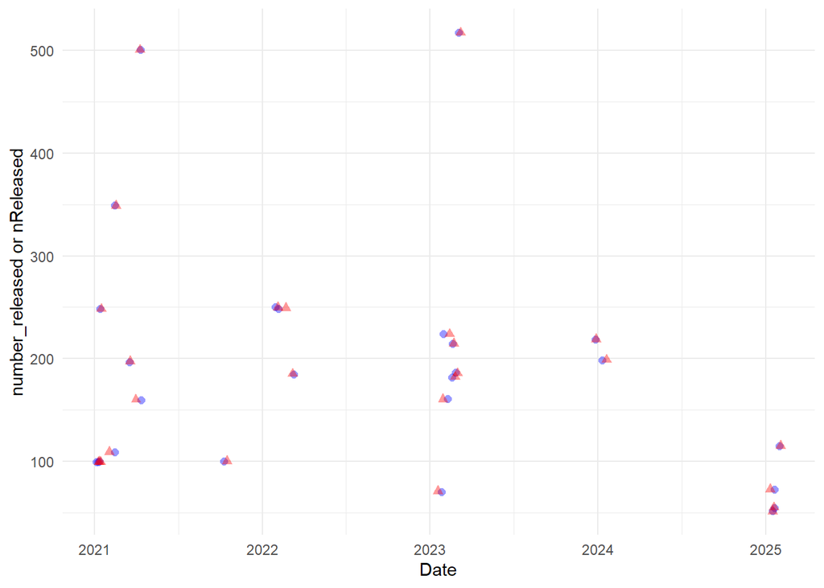

#### recapture

**- Findings:** - database earliest year is 2023, edi is 2021 - all fork length values are NA on both datasets

- Database date range (`recaptured_fish`)

```
## [1] "2023-01-25" "2024-01-20"
```

*date vs count/number_recapture*

- 0 % of values in the `count` column from the database are NA.
- 0 % of values in the `n` column from EDI are NA.

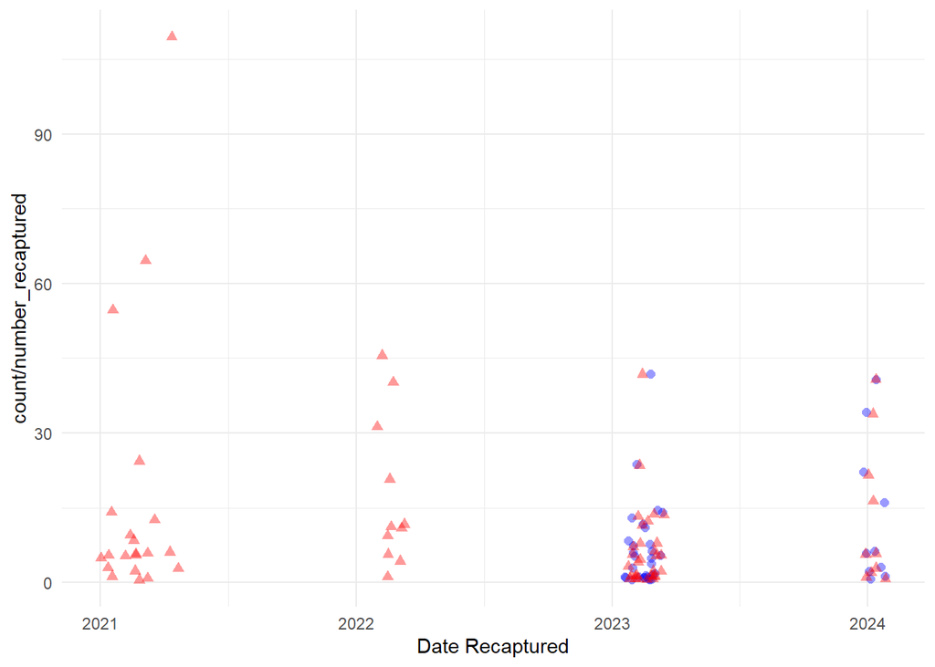

*fork_length*

- 100 % of values in the `fork_length` column from the database are NA.
- 100 % of values in the `forkLength` column from EDI are NA.

*lifestage*

- 0 % of values in the `lifestage_id` column from the database are NA.
- 0 % of values in the `lifeStage` column from EDI are NA.

Random pick of data entry to compare between db and EDI

- test 1

```
## Rows: 1
## Columns: 15
## $ id               <int> 248502
## $ trap_location_id <int> 8
## $ catch_raw_id     <int> 48132
## $ date             <date> 2023-03-01
## $ count            <dbl> 1
## $ run_id           <int> 2
## $ lifestage_id     <int> 4
## $ adipose_clipped  <lgl> FALSE
## $ dead             <lgl> TRUE
## $ fork_length      <dbl> NA
## $ weight           <dbl> NA
## $ release_id       <chr> "277"
## $ updated_at       <dttm> 2025-06-09 09:05:13
## $ stream           <chr> "butte creek"
## $ source           <chr> "DB"
```

```
## Rows: 1
## Columns: 22
## $ ProjectDescriptionID <dbl> 11
## $ catchRawID           <dbl> 48132
## $ trapVisitID          <dbl> 2314
## $ commonName           <chr> "Chinook salmon"
## $ releaseID            <dbl> 277
## $ atCaptureRun         <chr> "Spring"
## $ finalRun             <chr> NA
## $ fishOrigin           <chr> "Natural"
## $ lifeStage            <chr> "Not recorded"
## $ actualCount          <chr> "Yes"
## $ forkLength           <lgl> NA
## $ totalLength          <lgl> NA
## $ n                    <dbl> 1
## $ visitTime            <dttm> 2023-03-01 08:30:50
## $ visitType            <chr> "Continue trapping"
## $ siteName             <chr> "Parrott-Phelan canal trap box"
## $ subSiteName          <chr> "canal trap box"
## $ markType             <chr> "Pigment / dye"
## $ markColor            <chr> "Brown"
## $ markPosition         <chr> "Whole body"
## $ markCode             <lgl> NA
## $ source               <chr> "EDI"
```

- test 2

```
## Rows: 1
## Columns: 15
## $ id               <int> 248519
## $ trap_location_id <int> 6
## $ catch_raw_id     <int> 48250
## $ date             <date> 2023-03-03
## $ count            <dbl> 2
## $ run_id           <int> 2
## $ lifestage_id     <int> 4
## $ adipose_clipped  <lgl> FALSE
## $ dead             <lgl> TRUE
## $ fork_length      <dbl> NA
## $ weight           <dbl> NA
## $ release_id       <chr> "277"
## $ updated_at       <dttm> 2025-06-09 09:05:13
## $ stream           <chr> "butte creek"
## $ source           <chr> "DB"
```

```
## Rows: 1
## Columns: 22
## $ ProjectDescriptionID <dbl> 11
## $ catchRawID           <dbl> 48250
## $ trapVisitID          <dbl> 2317
## $ commonName           <chr> "Chinook salmon"
## $ releaseID            <dbl> 277
## $ atCaptureRun         <chr> "Spring"
## $ finalRun             <chr> NA
## $ fishOrigin           <chr> "Natural"
## $ lifeStage            <chr> "Not recorded"
## $ actualCount          <chr> "Yes"
## $ forkLength           <lgl> NA
## $ totalLength          <lgl> NA
## $ n                    <dbl> 2
## $ visitTime            <dttm> 2023-03-03 09:30:22
## $ visitType            <chr> "Unplanned restart"
## $ siteName             <chr> "Parrot-Phelan RST"
## $ subSiteName          <chr> "PP RST"
## $ markType             <chr> "Pigment / dye"
## $ markColor            <chr> "Brown"
## $ markPosition         <chr> "Whole body"
## $ markCode             <lgl> NA
## $ source               <chr> "EDI"
```

- test 3

```
## Rows: 1
## Columns: 15
## $ id               <int> 248513
## $ trap_location_id <int> 6
## $ catch_raw_id     <int> 46604
## $ date             <date> 2023-02-15
## $ count            <dbl> 11
## $ run_id           <int> 2
## $ lifestage_id     <int> 4
## $ adipose_clipped  <lgl> FALSE
## $ dead             <lgl> TRUE
## $ fork_length      <dbl> NA
## $ weight           <dbl> NA
## $ release_id       <chr> "275"
## $ updated_at       <dttm> 2025-06-09 09:05:13
## $ stream           <chr> "butte creek"
## $ source           <chr> "DB"
```

```
## Rows: 1
## Columns: 22
## $ ProjectDescriptionID <dbl> 11
## $ catchRawID           <dbl> 46604
## $ trapVisitID          <dbl> 2284
## $ commonName           <chr> "Chinook salmon"
## $ releaseID            <dbl> 275
## $ atCaptureRun         <chr> "Spring"
## $ finalRun             <chr> "Spring"
## $ fishOrigin           <chr> "Natural"
## $ lifeStage            <chr> "Not recorded"
## $ actualCount          <chr> "Yes"
## $ forkLength           <lgl> NA
## $ totalLength          <lgl> NA
## $ n                    <dbl> 11
## $ visitTime            <dttm> 2023-02-15 11:00:11
## $ visitType            <chr> "Continue trapping"
## $ siteName             <chr> "Parrot-Phelan RST"
## $ subSiteName          <chr> "PP RST"
## $ markType             <chr> "Pigment / dye"
## $ markColor            <chr> "Brown"
## $ markPosition         <chr> "Whole body"
## $ markCode             <lgl> NA
## $ source               <chr> "EDI"
```

- test 4

```
## Rows: 1
## Columns: 15
## $ id               <int> 248509
## $ trap_location_id <int> 6
## $ catch_raw_id     <int> 45421
## $ date             <date> 2023-02-01
## $ count            <dbl> 3
## $ run_id           <int> 2
## $ lifestage_id     <int> 4
## $ adipose_clipped  <lgl> FALSE
## $ dead             <lgl> TRUE
## $ fork_length      <dbl> NA
## $ weight           <dbl> NA
## $ release_id       <chr> "273"
## $ updated_at       <dttm> 2025-06-09 09:05:13
## $ stream           <chr> "butte creek"
## $ source           <chr> "DB"
```

```
## Rows: 1
## Columns: 22
## $ ProjectDescriptionID <dbl> 11
## $ catchRawID           <dbl> 45421
## $ trapVisitID          <dbl> 2257
## $ commonName           <chr> "Chinook salmon"
## $ releaseID            <dbl> 273
## $ atCaptureRun         <chr> "Spring"
## $ finalRun             <chr> "Not recorded"
## $ fishOrigin           <chr> "Natural"
## $ lifeStage            <chr> "Not recorded"
## $ actualCount          <chr> "Yes"
## $ forkLength           <lgl> NA
## $ totalLength          <lgl> NA
## $ n                    <dbl> 3
## $ visitTime            <dttm> 2023-02-01 12:00:59
## $ visitType            <chr> "Unplanned restart"
## $ siteName             <chr> "Parrot-Phelan RST"
## $ subSiteName          <chr> "PP RST"
## $ markType             <chr> "Pigment / dye"
## $ markColor            <chr> "Brown"
## $ markPosition         <chr> "Whole body"
## $ markCode             <lgl> NA
## $ source               <chr> "EDI"
```

### Feather River

#### catch

**- Findings catch:** - date range is different, will filter EDI to start 1999 for this data comparison purpose

- Database date range

```
## [1] "1999-06-05" "2025-05-16"
```

- EDI date range

```
## [1] "1997-12-23 11:40:00 UTC" "2025-05-16 13:15:12 UTC"
```

*forkLength*

EDI

- 14.8 % of values in the `forkLength` column are NA.

```
##    Min. 1st Qu.  Median    Mean 3rd Qu.    Max.    NA's
##    0.00   35.00   39.00   48.25   57.00  940.00   55834
```

DB

- 2.9 % of values in the `fork_length` column are NA.

```
##    Min. 1st Qu.  Median    Mean 3rd Qu.    Max.    NA's
##    0.00   35.00   37.00   42.84   45.00  880.00    1643
```

exploration plots

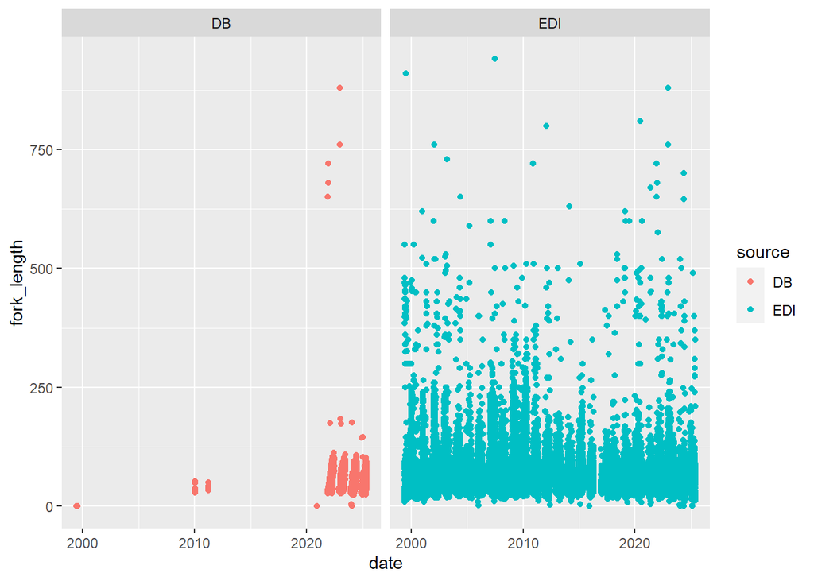

- 0 % of values in the `lifestage_id` column from the database are NA.

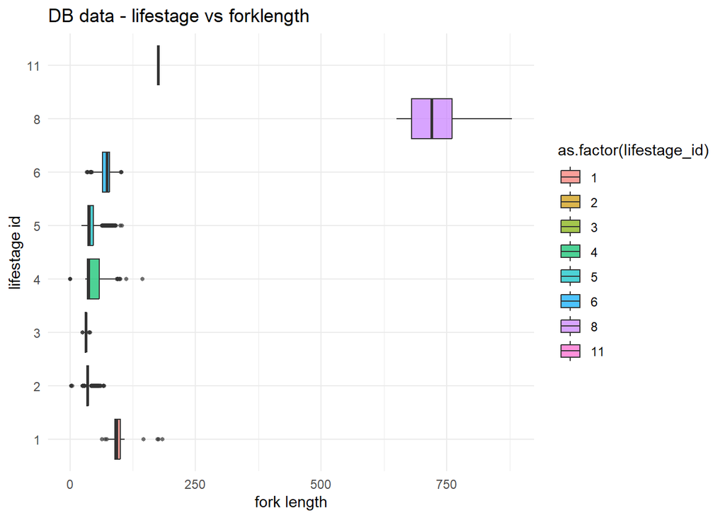

- 0 % of values in the `lifeStage` column from EDI are NA.

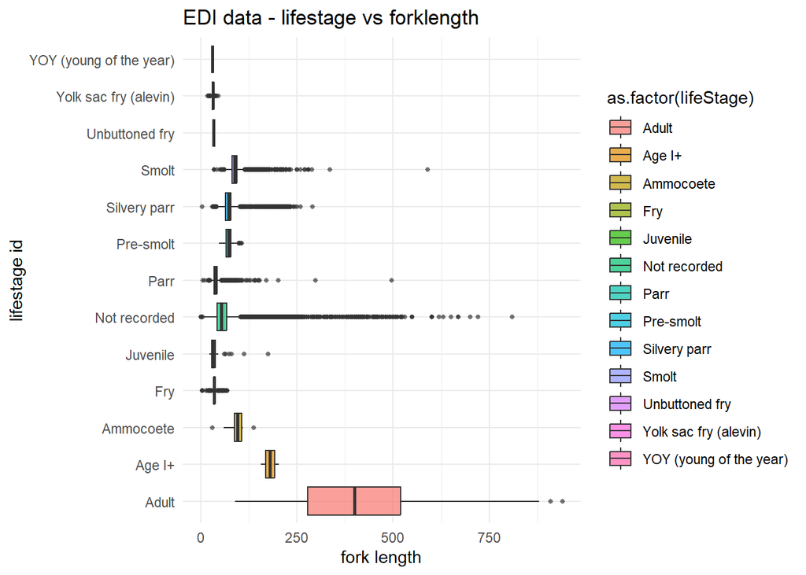

*count*

- 0 % of values in the `n` column in edi data are NA.

```
##      Min.   1st Qu.    Median      Mean   3rd Qu.      Max.
##      1.00      1.00      1.00     41.21      1.00 123556.00
```

- 0 % of values in the `count` column in database data are NA.

```
##     Min.  1st Qu.   Median     Mean  3rd Qu.     Max.
##     0.00     1.00     1.00    14.11     1.00 63879.00
```

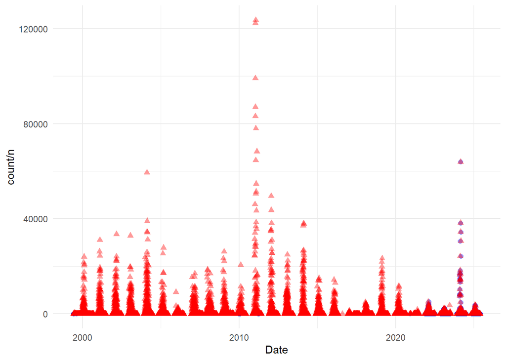

Random pick of data entry to compare between db and EDI

- test 1

```
## Rows: 1
## Columns: 15
## $ id               <int> 45467039
## $ catch_raw_id     <chr> "76944151"
## $ trap_location_id <int> 24
## $ date             <date> 2025-01-30
## $ count            <dbl> 1
## $ run_id           <int> 3
## $ lifestage_id     <int> 2
## $ adipose_clipped  <lgl> FALSE
## $ dead             <lgl> NA
## $ fork_length      <dbl> 35
## $ weight           <dbl> NA
## $ actual_count     <lgl> TRUE
## $ updated_at       <dttm> 2025-06-09 08:59:02
## $ stream           <chr> "feather river"
## $ source           <chr> "DB"
```

```
## Rows: 1
## Columns: 17
## $ ProjectDescriptionID <dbl> 2
## $ trapVisitID          <dbl> 10656
## $ visitTime            <dttm> 2025-01-30 12:07:53
## $ siteName             <chr> "Herringer Riffle"
## $ subSiteName          <chr> "Herringer_east"
## $ visitType            <chr> "End trapping"
## $ catchRawID           <dbl> 76944151
## $ commonName           <chr> "Chinook salmon"
## $ run                  <chr> "Fall"
## $ fishOrigin           <chr> "Natural"
## $ lifeStage            <chr> "Fry"
## $ forkLength           <dbl> 35
## $ totalLength          <dbl> NA
## $ n                    <dbl> 1
## $ actualCount          <chr> "Yes"
## $ releaseID            <dbl> 0
## $ source               <chr> "EDI"
```

- test 2

```
## Rows: 1
## Columns: 15
## $ id               <int> 45477524
## $ catch_raw_id     <chr> "76920264"
## $ trap_location_id <int> 18
## $ date             <date> 2024-03-04
## $ count            <dbl> 1
## $ run_id           <int> 3
## $ lifestage_id     <int> 5
## $ adipose_clipped  <lgl> FALSE
## $ dead             <lgl> NA
## $ fork_length      <dbl> 35
## $ weight           <dbl> NA
## $ actual_count     <lgl> TRUE
## $ updated_at       <dttm> 2025-06-09 08:59:02
## $ stream           <chr> "feather river"
## $ source           <chr> "DB"
```

```
## Rows: 1
## Columns: 17
## $ ProjectDescriptionID <dbl> 2
## $ trapVisitID          <dbl> 10206
## $ visitTime            <dttm> 2024-03-04 13:26:40
## $ siteName             <chr> "Eye Riffle"
## $ subSiteName          <chr> "Eye riffle_north"
## $ visitType            <chr> "Continue trapping"
## $ catchRawID           <dbl> 76920264
## $ commonName           <chr> "Chinook salmon"
## $ run                  <chr> "Fall"
## $ fishOrigin           <chr> "Natural"
## $ lifeStage            <chr> "Parr"
## $ forkLength           <dbl> 35
## $ totalLength          <dbl> NA
## $ n                    <dbl> 1
## $ actualCount          <chr> "Yes"
## $ releaseID            <dbl> 0
## $ source               <chr> "EDI"
```

- test 3

```
## Rows: 1
## Columns: 15
## $ id               <int> 45442835
## $ catch_raw_id     <chr> "76939998"
## $ trap_location_id <int> 25
## $ date             <date> 2010-01-11
## $ count            <dbl> 1
## $ run_id           <int> 3
## $ lifestage_id     <int> 2
## $ adipose_clipped  <lgl> FALSE
## $ dead             <lgl> NA
## $ fork_length      <dbl> 37
## $ weight           <dbl> NA
## $ actual_count     <lgl> TRUE
## $ updated_at       <dttm> 2025-06-09 08:59:02
## $ stream           <chr> "feather river"
## $ source           <chr> "DB"
```

```
## Rows: 1
## Columns: 17
## $ ProjectDescriptionID <dbl> 2
## $ trapVisitID          <dbl> 10601
## $ visitTime            <dttm> 2010-01-11 10:12:06
## $ siteName             <chr> "Herringer Riffle"
## $ subSiteName          <chr> "Herringer_Upper_west"
## $ visitType            <chr> "Continue trapping"
## $ catchRawID           <dbl> 76939998
## $ commonName           <chr> "Chinook salmon"
## $ run                  <chr> "Fall"
## $ fishOrigin           <chr> "Natural"
## $ lifeStage            <chr> "Fry"
## $ forkLength           <dbl> 37
## $ totalLength          <dbl> NA
## $ n                    <dbl> 1
## $ actualCount          <chr> "Yes"
## $ releaseID            <dbl> 255
## $ source               <chr> "EDI"
```

- test 4

```
## Rows: 1
## Columns: 15
## $ id               <int> 45443080
## $ catch_raw_id     <chr> "76868549"
## $ trap_location_id <int> 25
## $ date             <date> 2022-01-04
## $ count            <dbl> 1
## $ run_id           <int> 3
## $ lifestage_id     <int> 2
## $ adipose_clipped  <lgl> FALSE
## $ dead             <lgl> NA
## $ fork_length      <dbl> 32
## $ weight           <dbl> NA
## $ actual_count     <lgl> TRUE
## $ updated_at       <dttm> 2025-06-09 08:59:02
## $ stream           <chr> "feather river"
## $ source           <chr> "DB"
```

```
## Rows: 1
## Columns: 17
## $ ProjectDescriptionID <dbl> 2
## $ trapVisitID          <dbl> 9169
## $ visitTime            <dttm> 2022-01-04 12:10:04
## $ siteName             <chr> "Herringer Riffle"
## $ subSiteName          <chr> "Herringer_Upper_west"
## $ visitType            <chr> "Continue trapping"
## $ catchRawID           <dbl> 76868549
## $ commonName           <chr> "Chinook salmon"
## $ run                  <chr> "Fall"
## $ fishOrigin           <chr> "Natural"
## $ lifeStage            <chr> "Fry"
## $ forkLength           <dbl> 32
## $ totalLength          <dbl> NA
## $ n                    <dbl> 1
## $ actualCount          <chr> "Yes"
## $ releaseID            <dbl> 0
## $ source               <chr> "EDI"
```

#### trap

**- Findings trap:** - date range is different - db data has different time range on `trap_visit_time_start` and `trap_visit_time_end`, wondering which one we should be comparing to edi

Database

```
## Rows: 1,712
## Columns: 22
## $ id                         <int> 2023630, 2023637, 2023644, 2043138, 2043145…
## $ trap_location_id           <int> 77, 77, 77, 77, 77, 77, 77, 77, 77, 18, 18,…
## $ trap_visit_id              <chr> NA, NA, NA, NA, NA, NA, NA, NA, NA, "9912",…
## $ visit_type_id              <int> NA, NA, NA, NA, NA, NA, NA, NA, NA, 2, 3, 2…
## $ trap_visit_time_start      <dttm> NA, NA, NA, NA, NA, NA, NA, NA, NA, 2023-0…
## $ trap_visit_time_end        <dttm> NA, NA, 2020-11-27 08:00:00, NA, NA, 2020-…
## $ trap_functioning_id        <int> 2, 5, 5, 2, 5, 5, 2, 5, 5, 2, 2, 2, 2, 2, 2…
## $ in_half_cone_configuration <lgl> TRUE, FALSE, FALSE, TRUE, FALSE, FALSE, TRU…
## $ fish_processed_id          <int> NA, NA, NA, NA, NA, NA, NA, NA, NA, 2, 2, 2…
## $ rpm_start                  <dbl> NA, NA, NA, NA, NA, NA, NA, NA, NA, 6.1, 2.…
## $ rpm_end                    <dbl> NA, NA, NA, NA, NA, NA, NA, NA, NA, 5.1, NA…
## $ total_revolutions          <dbl> NA, NA, NA, NA, NA, NA, NA, NA, NA, 7790, 2…
## $ debris_volume              <dbl> NA, NA, NA, NA, NA, NA, NA, NA, NA, NA, NA,…
## $ debris_level_id            <int> NA, NA, NA, NA, NA, NA, NA, NA, NA, NA, NA,…
## $ discharge                  <dbl> NA, NA, NA, NA, NA, NA, NA, NA, NA, NA, NA,…
## $ water_velocity             <dbl> NA, NA, NA, NA, NA, NA, NA, NA, NA, NA, NA,…
## $ water_temp                 <dbl> NA, NA, NA, NA, NA, NA, NA, NA, NA, NA, 14.…
## $ turbidity                  <dbl> NA, NA, NA, NA, NA, NA, NA, NA, NA, NA, 1.7…
## $ include                    <lgl> FALSE, FALSE, FALSE, FALSE, FALSE, FALSE, F…
## $ updated_at                 <dttm> 2025-06-03 19:15:19, 2025-06-03 19:15:19, …
## $ updated_by                 <chr> "AdminJPE", "AdminJPE", "AdminJPE", "AdminJ…
## $ stream                     <chr> "feather river", "feather river", "feather …
```

- Database date range (`trap_visit_time_end`)

```
## [1] "2020-11-27 08:00:00 UTC" "2020-11-27 08:00:00 UTC"
```

- Database date range (`trap_visit_time_start`)

```
## [1] "2010-01-11 10:12:06 UTC" "2025-05-16 13:15:12 UTC"
```

EDI

```
## Rows: 10,423
## Columns: 14
## $ projectDescriptionID  <dbl> 2, 2, 2, 2, 2, 2, 2, 2, 2, 2, 2, 2, 2, 2, 2, 2, …
## $ trapVisitID           <dbl> 1, 2, 3, 4, 5, 6, 7, 8, 9, 10, 11, 12, 13, 14, 1…
## $ visitTime             <dttm> 1997-12-22 10:40:00, 1997-12-22 16:48:00, 1997-…
## $ siteName              <chr> "Eye Riffle", "Live Oak", "Eye Riffle", "Live Oa…
## $ subSiteName           <chr> "Eye riffle_north", "Live Oak", "Eye riffle_nort…
## $ visitType             <chr> "Start trap & begin trapping", "Start trap & beg…
## $ fishProcessed         <chr> "Not applicable", "Not applicable", "Processed f…
## $ trapFunctioning       <chr> "Trap not in service", "Trap not in service", "N…
## $ counterAtEnd          <dbl> NA, NA, NA, 2917, NA, NA, 1826, NA, 1873, 2522, …
## $ rpmRevolutionsAtStart <dbl> NA, NA, NA, NA, NA, NA, NA, NA, NA, NA, NA, NA, …
## $ rpmRevolutionsAtEnd   <dbl> NA, NA, 1.5, 2.8, NA, NA, 2.2, 2.2, 1.6, 1.5, 1.…
## $ includeCatch          <chr> "Yes", "Yes", "Yes", "Yes", "Yes", "Yes", "Yes",…
## $ waterTemp             <dbl> NA, NA, 8.888889, 8.888889, NA, NA, 7.777778, 7.…
## $ turbidity             <dbl> NA, NA, NA, NA, NA, NA, NA, NA, NA, NA, NA, NA, …
```

- EDI date range (`visitTime`)

```
## [1] "1997-12-22 10:40:00 UTC" "2025-05-16 13:15:12 UTC"
```

*water_temp*

DB

```
##    Min. 1st Qu.  Median    Mean 3rd Qu.    Max.    NA's
##     0.9     9.0    10.0    10.8    12.0    25.0      45
```

EDI

```
##    Min. 1st Qu.  Median    Mean 3rd Qu.    Max.    NA's
##    0.00    9.00   10.50   11.34   13.00   25.00    1042
```

*turbidity*

DB

```
##     Min.  1st Qu.   Median     Mean  3rd Qu.     Max.     NA's
##    0.300    1.820    2.540    6.844    3.545 6650.000       37
```

EDI

```
##     Min.  1st Qu.   Median     Mean  3rd Qu.     Max.     NA's
##    0.000    1.510    2.350    3.818    3.580 6650.000     2003
```

#### release

**- Findings release:** - date range is different - edi has only two data entries earlier than 2011 (1999 and 1900). Wondering is these are worth keeping? (DB has one 1999 data entry) - all `median_fork_length_released` values on DB are NA. No fork_length field on EDI - all `lifestage_id` values on DB are NA. No lifestage field on EDI - data fields seem different among the two datasets

- Database date range

```
## [1] "1999-02-04 17:00:00 UTC" "2025-04-10 10:12:00 UTC"
```

*number_released and nReleased*

- 0 % of values in the `number_released` column in the database dataset are NA.
- 0 % of values in the `nReleased` column in the EDI dataset are NA.

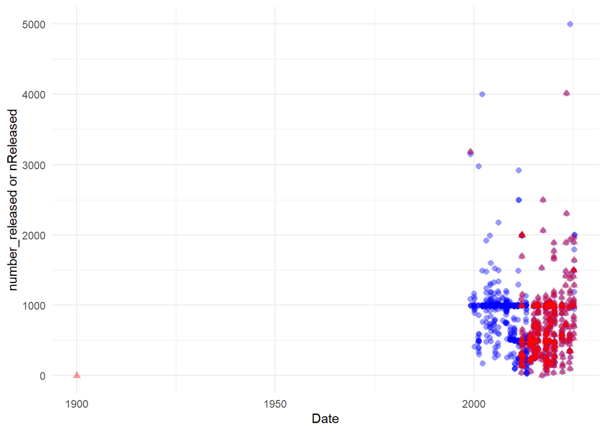

Column names DB

```
##  [1] "id"                          "trap_location_id"
##  [3] "release_id"                  "date_released"
##  [5] "run_id"                      "median_fork_length_released"
##  [7] "lifestage_id"                "origin_id"
##  [9] "number_released"             "updated_at"
## [11] "updated_by"                  "stream"
```

Column names EDI

```
##  [1] "projectDescriptionID" "releaseID"            "releaseTime"
##  [4] "commonName"           "markedRun"            "markedFishOrigin"
##  [7] "sourceOfFishSite"     "releaseSite"          "releaseSubSite"
## [10] "nReleased"            "testDays"             "appliedMarkType"
## [13] "appliedMarkColor"     "appliedMarkPosition"  "appliedMarkCode"
## [16] "IncludeInAnalysis"
```

Random pick of data entry to compare between db and EDI

- test 1

```
## Rows: 1
## Columns: 13
## $ id                          <int> 62534
## $ trap_location_id            <int> 30
## $ release_id                  <chr> "341"
## $ date_released               <dttm> 2011-12-07 11:45:00
## $ run_id                      <int> 3
## $ median_fork_length_released <dbl> NA
## $ lifestage_id                <int> NA
## $ origin_id                   <int> 1
## $ number_released             <dbl> 193
## $ updated_at                  <dttm> 2025-06-09 08:59:41
## $ updated_by                  <chr> "AdminJPE"
## $ stream                      <chr> "feather river"
## $ source                      <chr> "DB"
```

```
## Rows: 1
## Columns: 17
## $ projectDescriptionID <dbl> 2
## $ releaseID            <dbl> 341
## $ releaseTime          <dttm> 2011-12-07 11:45:00
## $ commonName           <chr> "Chinook salmon"
## $ markedRun            <chr> "Fall"
## $ markedFishOrigin     <chr> "Natural"
## $ sourceOfFishSite     <chr> "Steep Riffle"
## $ releaseSite          <chr> "Steep Riffle_release site"
## $ releaseSubSite       <chr> "Not applicable (n/a)"
## $ nReleased            <dbl> 193
## $ testDays             <dbl> 7
## $ appliedMarkType      <chr> "Elastomer"
## $ appliedMarkColor     <chr> "Green"
## $ appliedMarkPosition  <chr> "Nose"
## $ appliedMarkCode      <lgl> NA
## $ IncludeInAnalysis    <chr> "No"
## $ source               <chr> "EDI"
```

- test 2

```
## Rows: 1
## Columns: 13
## $ id                          <int> 62966
## $ trap_location_id            <int> 20
## $ release_id                  <chr> "910"
## $ date_released               <dttm> 2024-01-19 10:17:00
## $ run_id                      <int> 3
## $ median_fork_length_released <dbl> NA
## $ lifestage_id                <int> NA
## $ origin_id                   <int> 1
## $ number_released             <dbl> 444
## $ updated_at                  <dttm> 2025-06-09 08:59:41
## $ updated_by                  <chr> "AdminJPE"
## $ stream                      <chr> "feather river"
## $ source                      <chr> "DB"
```

```
## Rows: 1
## Columns: 17
## $ projectDescriptionID <dbl> 2
## $ releaseID            <dbl> 910
## $ releaseTime          <dttm> 2024-01-19 10:17:00
## $ commonName           <chr> "Chinook salmon"
## $ markedRun            <chr> "Fall"
## $ markedFishOrigin     <chr> "Natural"
## $ sourceOfFishSite     <chr> "Eye Riffle"
## $ releaseSite          <chr> "Eye riffle_release site"
## $ releaseSubSite       <chr> "Below Weir Riffle"
## $ nReleased            <dbl> 444
## $ testDays             <dbl> 7
## $ appliedMarkType      <chr> "Elastomer"
## $ appliedMarkColor     <chr> "Pink"
## $ appliedMarkPosition  <chr> "Nose"
## $ appliedMarkCode      <lgl> NA
## $ IncludeInAnalysis    <chr> "Yes"
## $ source               <chr> "EDI"
```

- test 3

```
## Rows: 1
## Columns: 17
## $ projectDescriptionID <dbl> 2
## $ releaseID            <dbl> 696
## $ releaseTime          <dttm> 2018-01-11 11:15:00
## $ commonName           <chr> "Chinook salmon"
## $ markedRun            <chr> "Fall"
## $ markedFishOrigin     <chr> "Natural"
## $ sourceOfFishSite     <chr> "Eye Riffle"
## $ releaseSite          <chr> "Eye riffle_release site"
## $ releaseSubSite       <chr> "Below Weir Riffle"
## $ nReleased            <dbl> 481
## $ testDays             <dbl> 7
## $ appliedMarkType      <chr> "Elastomer"
## $ appliedMarkColor     <chr> "Blue"
## $ appliedMarkPosition  <chr> "Nose"
## $ appliedMarkCode      <lgl> NA
## $ IncludeInAnalysis    <chr> "Yes"
## $ source               <chr> "EDI"
```

```
## Rows: 1
## Columns: 13
## $ id                          <int> 62752
## $ trap_location_id            <int> 20
## $ release_id                  <chr> "696"
## $ date_released               <dttm> 2018-01-11 11:15:00
## $ run_id                      <int> 3
## $ median_fork_length_released <dbl> NA
## $ lifestage_id                <int> NA
## $ origin_id                   <int> 1
## $ number_released             <dbl> 481
## $ updated_at                  <dttm> 2025-06-09 08:59:41
## $ updated_by                  <chr> "AdminJPE"
## $ stream                      <chr> "feather river"
## $ source                      <chr> "DB"
```

- test 4

```
## Rows: 1
## Columns: 17
## $ projectDescriptionID <dbl> 2
## $ releaseID            <dbl> 606
## $ releaseTime          <dttm> 2015-01-21 16:18:00
## $ commonName           <chr> "Chinook salmon"
## $ markedRun            <chr> "Fall"
## $ markedFishOrigin     <chr> "Natural"
## $ sourceOfFishSite     <chr> "Gateway Riffle"
## $ releaseSite          <chr> "Herringer_release site"
## $ releaseSubSite       <chr> "Herringer release_ RL & RR"
## $ nReleased            <dbl> 981
## $ testDays             <dbl> 4
## $ appliedMarkType      <chr> "Elastomer"
## $ appliedMarkColor     <chr> "White"
## $ appliedMarkPosition  <chr> "Nose"
## $ appliedMarkCode      <lgl> NA
## $ IncludeInAnalysis    <chr> "Yes"
## $ source               <chr> "EDI"
```

```
## Rows: 1
## Columns: 13
## $ id                          <int> 62654
## $ trap_location_id            <int> 26
## $ release_id                  <chr> "606"
## $ date_released               <dttm> 2015-01-21 16:18:00
## $ run_id                      <int> 3
## $ median_fork_length_released <dbl> NA
## $ lifestage_id                <int> NA
## $ origin_id                   <int> 1
## $ number_released             <dbl> 981
## $ updated_at                  <dttm> 2025-06-09 08:59:41
## $ updated_by                  <chr> "AdminJPE"
## $ stream                      <chr> "feather river"
## $ source                      <chr> "DB"
```

#### recapture

**- Findings:** - date range is different (database start year is 2022, and EDI is 1999). Some filtering was done to focus data comparison within the same time period - `fork_length` and `lifestage` values match between the two datasets

- Database date range (`recaptured_fish`)

```
## [1] "2022-01-06" "2025-03-29"
```

- EDI date range (`current_year_feather_recapture.csv`)

```
## [1] "1999-02-05 10:15:00 UTC" "2025-03-29 10:57:12 UTC"
```

column names DB

```
##  [1] "id"               "trap_location_id" "catch_raw_id"     "date"
##  [5] "count"            "run_id"           "lifestage_id"     "adipose_clipped"
##  [9] "dead"             "fork_length"      "weight"           "release_id"
## [13] "updated_at"       "stream"
```

column names EDI

```
##  [1] "ProjectDescriptionID" "catchRawID"           "trapVisitID"
##  [4] "commonName"           "releaseID"            "run"
##  [7] "fishOrigin"           "lifeStage"            "forkLength"
## [10] "n"                    "visitTime"            "visitType"
## [13] "siteName"             "subSiteName"          "markType"
## [16] "markColor"            "markPosition"         "markCode"
```

*date vs count/number_recapture*

- 0 % of values in the `count` column from the database are NA.
- 0 % of values in the `n` column from EDI are NA.

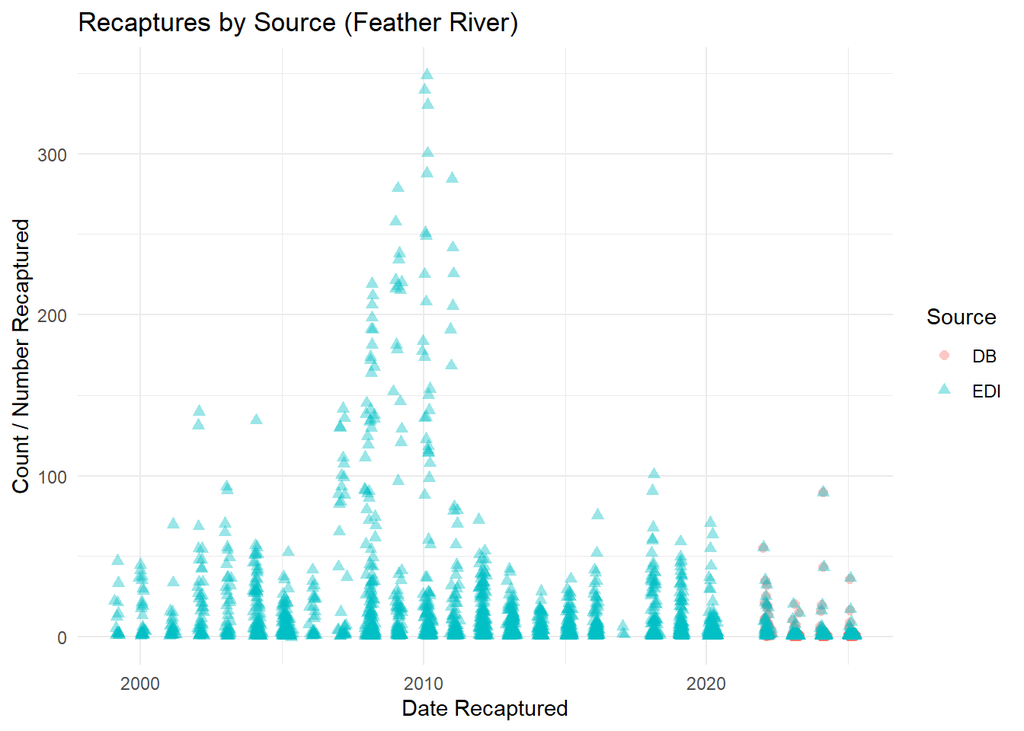

*fork_length*

- 10.7 % of values in the `fork_length` column from the database are NA.
- 74.1 % of values in the `forkLength` column from EDI are NA.

*lifestage*

- 0 % of values in the `lifestage_id` column from the database are NA.
- 0 % of values in the `lifeStage` column from EDI are NA.

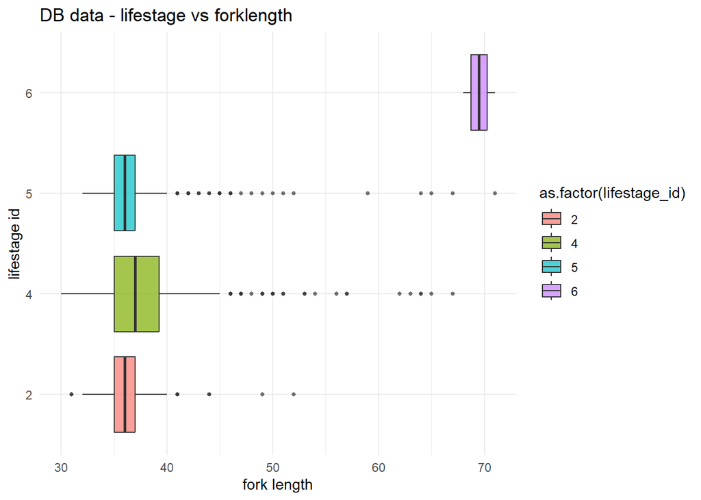

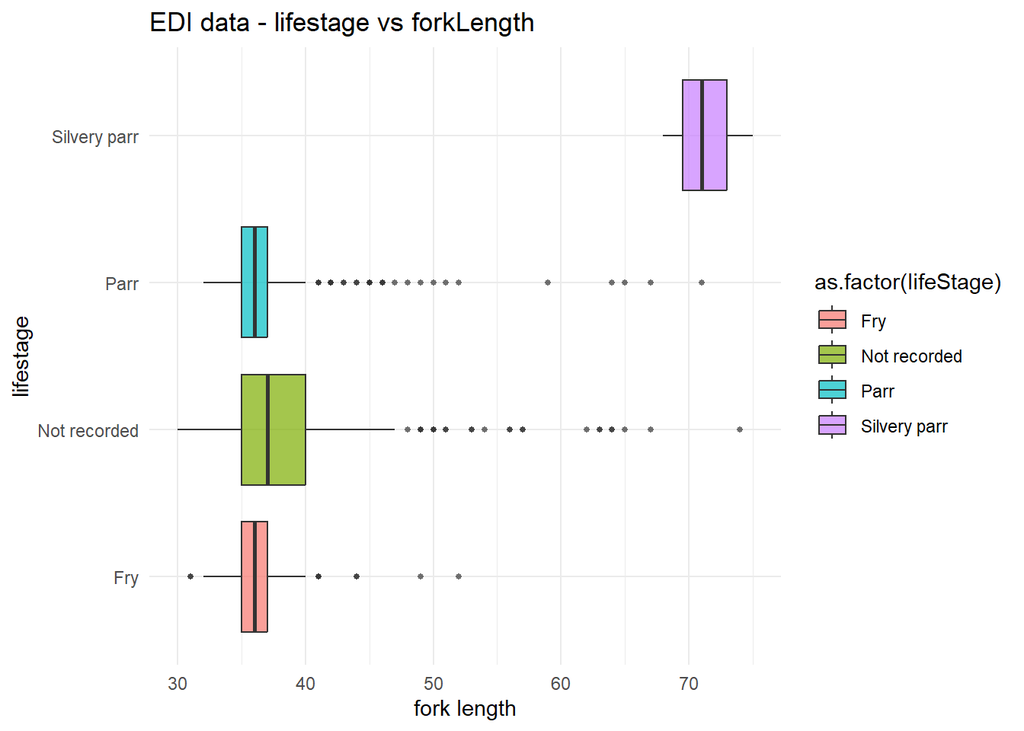

Note that EDI has been filtered to start date of 2022 to match database temporal coverage

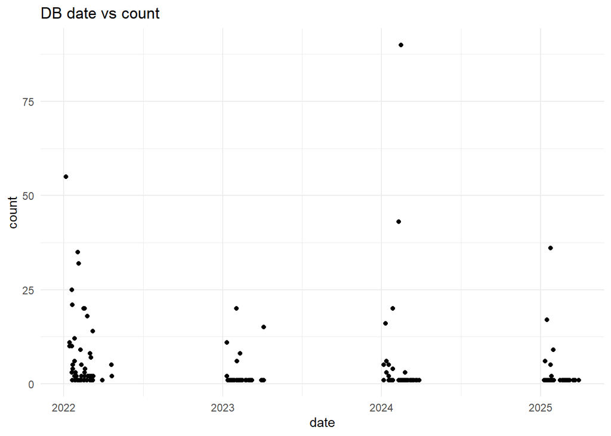

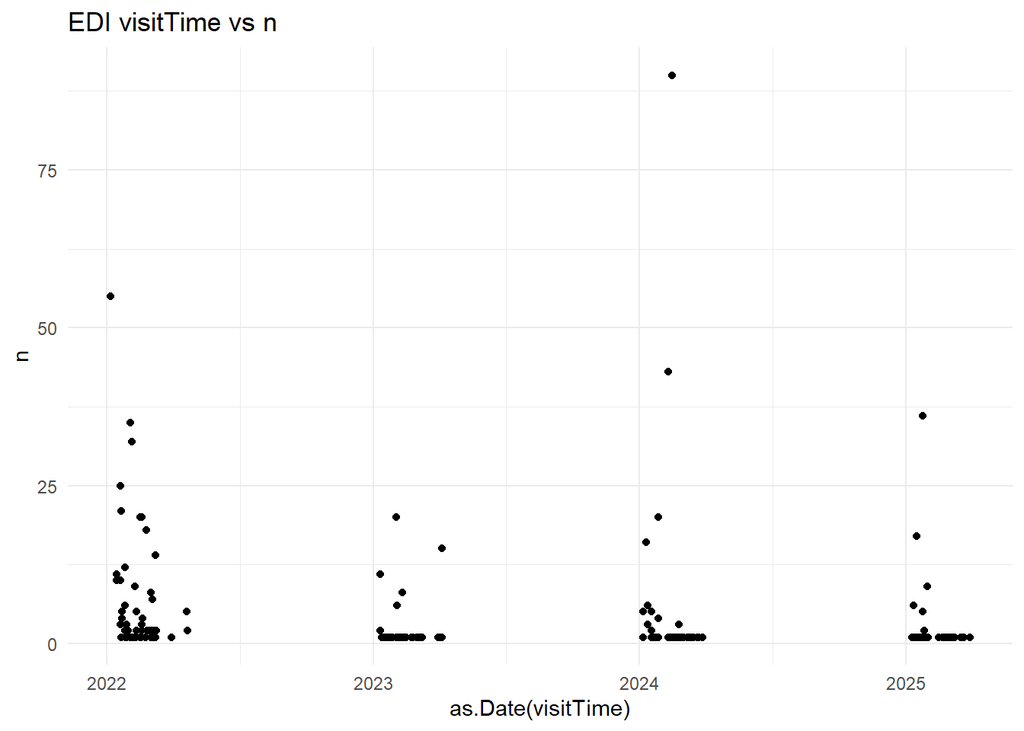

Random pick of data entry to compare between db and EDI

- test 1

```
## Rows: 1
## Columns: 15
## $ id               <int> 243106
## $ trap_location_id <int> 18
## $ catch_raw_id     <int> 76868063
## $ date             <date> 2022-01-06
## $ count            <dbl> 55
## $ run_id           <int> 3
## $ lifestage_id     <int> 4
## $ adipose_clipped  <lgl> FALSE
## $ dead             <lgl> NA
## $ fork_length      <dbl> NA
## $ weight           <dbl> NA
## $ release_id       <chr> "856"
## $ updated_at       <dttm> 2025-06-09 08:59:40
## $ stream           <chr> "feather river"
## $ source           <chr> "DB"
```

```
## Rows: 1
## Columns: 21
## $ ProjectDescriptionID <dbl> 2
## $ catchRawID           <dbl> 76868063
## $ trapVisitID          <dbl> 9152
## $ commonName           <chr> "Chinook salmon"
## $ releaseID            <dbl> 856
## $ run                  <chr> "Fall"
## $ fishOrigin           <chr> "Natural"
## $ lifeStage            <chr> "Not recorded"
## $ forkLength           <dbl> NA
## $ n                    <dbl> 55
## $ visitTime            <dttm> 2022-01-06 11:00:40
## $ visitType            <chr> "Continue trapping"
## $ siteName             <chr> "Eye Riffle"
## $ subSiteName          <chr> "Eye riffle_north"
## $ markType             <chr> "Pigment / dye"
## $ markColor            <chr> "Brown"
## $ markPosition         <chr> "Whole body"
## $ markCode             <lgl> NA
## $ source               <chr> "EDI"
## $ date                 <date> 2022-01-06
## $ count                <dbl> 55
```

- test 2

```
## Rows: 1
## Columns: 15
## $ id               <int> 243365
## $ trap_location_id <int> 18
## $ catch_raw_id     <int> 76901705
## $ date             <date> 2023-03-02
## $ count            <dbl> 1
## $ run_id           <int> 5
## $ lifestage_id     <int> 5
## $ adipose_clipped  <lgl> FALSE
## $ dead             <lgl> NA
## $ fork_length      <dbl> 35
## $ weight           <dbl> NA
## $ release_id       <chr> "895"
## $ updated_at       <dttm> 2025-06-09 08:59:40
## $ stream           <chr> "feather river"
## $ source           <chr> "DB"
```

```
## Rows: 1
## Columns: 21
## $ ProjectDescriptionID <dbl> 2
## $ catchRawID           <dbl> 76901705
## $ trapVisitID          <dbl> 9778
## $ commonName           <chr> "Chinook salmon"
## $ releaseID            <dbl> 895
## $ run                  <chr> NA
## $ fishOrigin           <chr> "Natural"
## $ lifeStage            <chr> "Parr"
## $ forkLength           <dbl> 35
## $ n                    <dbl> 1
## $ visitTime            <dttm> 2023-03-02 11:52:07
## $ visitType            <chr> "Continue trapping"
## $ siteName             <chr> "Eye Riffle"
## $ subSiteName          <chr> "Eye riffle_north"
## $ markType             <chr> "Elastomer"
## $ markColor            <chr> "Orange"
## $ markPosition         <chr> "Nose"
## $ markCode             <lgl> NA
## $ source               <chr> "EDI"
## $ date                 <date> 2023-03-02
## $ count                <dbl> 1
```

- test 3

```
## Rows: 1
## Columns: 15
## $ id               <int> 243511
## $ trap_location_id <int> 24
## $ catch_raw_id     <int> 76918872
## $ date             <date> 2024-02-23
## $ count            <dbl> 1
## $ run_id           <int> 5
## $ lifestage_id     <int> 5
## $ adipose_clipped  <lgl> FALSE
## $ dead             <lgl> NA
## $ fork_length      <dbl> 34
## $ weight           <dbl> NA
## $ release_id       <chr> "924"
## $ updated_at       <dttm> 2025-06-09 08:59:40
## $ stream           <chr> "feather river"
## $ source           <chr> "DB"
```

```
## Rows: 1
## Columns: 21
## $ ProjectDescriptionID <dbl> 2
## $ catchRawID           <dbl> 76918872
## $ trapVisitID          <dbl> 10184
## $ commonName           <chr> "Chinook salmon"
## $ releaseID            <dbl> 924
## $ run                  <chr> NA
## $ fishOrigin           <chr> "Natural"
## $ lifeStage            <chr> "Parr"
## $ forkLength           <dbl> 34
## $ n                    <dbl> 1
## $ visitTime            <dttm> 2024-02-23 10:07:15
## $ visitType            <chr> "Continue trapping"
## $ siteName             <chr> "Herringer Riffle"
## $ subSiteName          <chr> "Herringer_east"
## $ markType             <chr> "Elastomer"
## $ markColor            <chr> "White"
## $ markPosition         <chr> "Nose"
## $ markCode             <lgl> NA
## $ source               <chr> "EDI"
## $ date                 <date> 2024-02-23
## $ count                <dbl> 1
```

- test 4

```
## Rows: 1
## Columns: 15
## $ id               <int> 243159
## $ trap_location_id <int> 18
## $ catch_raw_id     <int> 76880944
## $ date             <date> 2022-03-10
## $ count            <dbl> 2
## $ run_id           <int> 3
## $ lifestage_id     <int> 4
## $ adipose_clipped  <lgl> FALSE
## $ dead             <lgl> NA
## $ fork_length      <dbl> NA
## $ weight           <dbl> NA
## $ release_id       <chr> "882"
## $ updated_at       <dttm> 2025-06-09 08:59:40
## $ stream           <chr> "feather river"
## $ source           <chr> "DB"
```

```
## Rows: 1
## Columns: 21
## $ ProjectDescriptionID <dbl> 2
## $ catchRawID           <dbl> 76880944
## $ trapVisitID          <dbl> 9354
## $ commonName           <chr> "Chinook salmon"
## $ releaseID            <dbl> 882
## $ run                  <chr> "Fall"
## $ fishOrigin           <chr> "Natural"
## $ lifeStage            <chr> "Not recorded"
## $ forkLength           <dbl> NA
## $ n                    <dbl> 2
## $ visitTime            <dttm> 2022-03-10 10:01:30
## $ visitType            <chr> "Continue trapping"
## $ siteName             <chr> "Eye Riffle"
## $ subSiteName          <chr> "Eye riffle_north"
## $ markType             <chr> "Elastomer"
## $ markColor            <chr> "Pink"
## $ markPosition         <chr> "Nose"
## $ markCode             <lgl> NA
## $ source               <chr> "EDI"
## $ date                 <date> 2022-03-10
## $ count                <dbl> 2
```

### Yuba

#### catch

**- Findings catch:** - date range is different, will filter EDI to start 1999 for this data comparison purpose

- Database date range

```
## Rows: 32,552
## Columns: 14
## $ id               <int> 45500304, 45500305, 45500306, 45500307, 45500308, 455…
## $ catch_raw_id     <chr> "299.0", "303.0", "301.0", "302.0", "312.0", "320.0",…
## $ trap_location_id <int> 49, 49, 49, 49, 49, 49, 49, 49, 49, 49, 49, 49, 49, 4…
## $ date             <date> 2022-11-22, 2022-11-23, 2022-11-23, 2022-11-23, 2022…
## $ count            <dbl> 1, 1, 1, 1, 1, 1, 1, 1, 1, 1, 1, 1, 1, 1, 1, 1, 1, 1,…
## $ run_id           <int> 2, 2, 2, 2, 2, 2, 2, 2, 2, 2, 2, 2, 2, 2, 2, 2, 2, 2,…
## $ lifestage_id     <int> 5, 5, 5, 5, 5, 5, 5, 5, 5, 5, 5, 5, 5, 5, 5, 5, 5, 5,…
## $ adipose_clipped  <lgl> FALSE, FALSE, FALSE, FALSE, FALSE, FALSE, FALSE, FALS…
## $ dead             <lgl> NA, NA, NA, NA, NA, NA, NA, NA, NA, NA, NA, NA, NA, N…
## $ fork_length      <dbl> 34, 35, 35, 36, 35, 33, 33, 35, 32, 36, 33, 31, 33, 3…
## $ weight           <dbl> NA, NA, NA, NA, NA, NA, NA, NA, NA, NA, NA, NA, NA, N…
## $ actual_count     <lgl> TRUE, TRUE, TRUE, TRUE, TRUE, TRUE, TRUE, TRUE, TRUE,…
## $ updated_at       <dttm> 2025-06-09 08:59:50, 2025-06-09 08:59:50, 2025-06-09…
## $ stream           <chr> "yuba river", "yuba river", "yuba river", "yuba river…
```

```
##     min_date   max_date
## 1 1999-06-05 2025-05-23
```

- EDI date range

```
## Rows: 140,335
## Columns: 16
## $ visitTime            <dttm> 1999-11-25 12:00:00, 1999-11-25 12:00:00, 1999-1…
## $ run                  <chr> "Not recorded", "Not recorded", "Not recorded", "…
## $ forkLength           <dbl> 35, 37, 38, 30, 33, 34, 35, 38, 34, 35, 36, 37, 3…
## $ lifeStage            <chr> "Not recorded", "Not recorded", "Not recorded", "…
## $ n                    <dbl> 4, 3, 4, 2, 2, 2, 11, 4, 17, 49, 50, 40, 47, 20, …
## $ siteName             <chr> "Yuba River", "Yuba River", "Yuba River", "Yuba R…
## $ subSiteName          <chr> "Yuba River", "Yuba River", "Yuba River", "Yuba R…
## $ fishOrigin           <chr> "Natural", "Natural", "Natural", "Natural", "Natu…
## $ commonName           <chr> "Chinook salmon", "Chinook salmon", "Chinook salm…
## $ releaseID            <dbl> NA, NA, NA, NA, NA, NA, NA, NA, NA, NA, NA, NA, N…
## $ ProjectDescriptionID <dbl> NA, NA, NA, NA, NA, NA, NA, NA, NA, NA, NA, NA, N…
## $ trapVisitID          <dbl> NA, NA, NA, NA, NA, NA, NA, NA, NA, NA, NA, NA, N…
## $ visitType            <chr> NA, NA, NA, NA, NA, NA, NA, NA, NA, NA, NA, NA, N…
## $ catchRawID           <dbl> NA, NA, NA, NA, NA, NA, NA, NA, NA, NA, NA, NA, N…
## $ totalLength          <dbl> NA, NA, NA, NA, NA, NA, NA, NA, NA, NA, NA, NA, N…
## $ actualCount          <chr> NA, NA, NA, NA, NA, NA, NA, NA, NA, NA, NA, NA, N…
```

```
## [1] "1999-11-25 12:00:00 UTC" "2025-05-23 10:51:30 UTC"
```

*fork_length*

EDI

- 3.4 % of values in the `forkLength` column are NA.

```
##    Min. 1st Qu.  Median    Mean 3rd Qu.    Max.    NA's
##    1.00   36.00   41.00   49.04   61.00  723.00    4784
```

DB

- 2 % of values in the `fork_length` column are NA.

```
##    Min. 1st Qu.  Median    Mean 3rd Qu.    Max.    NA's
##    0.00   35.00   37.00   42.35   42.00  454.00     640
```

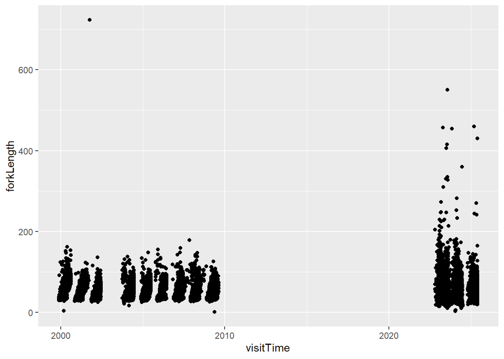

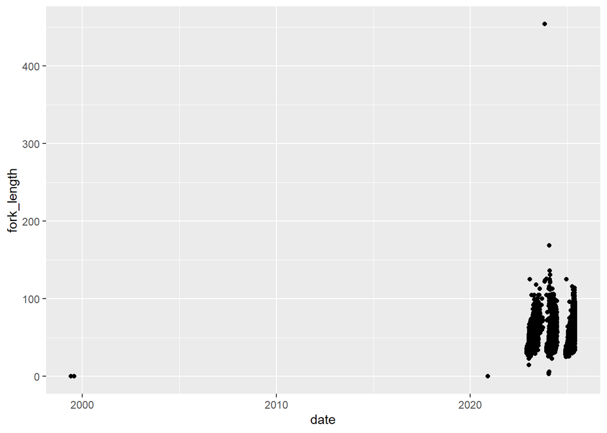

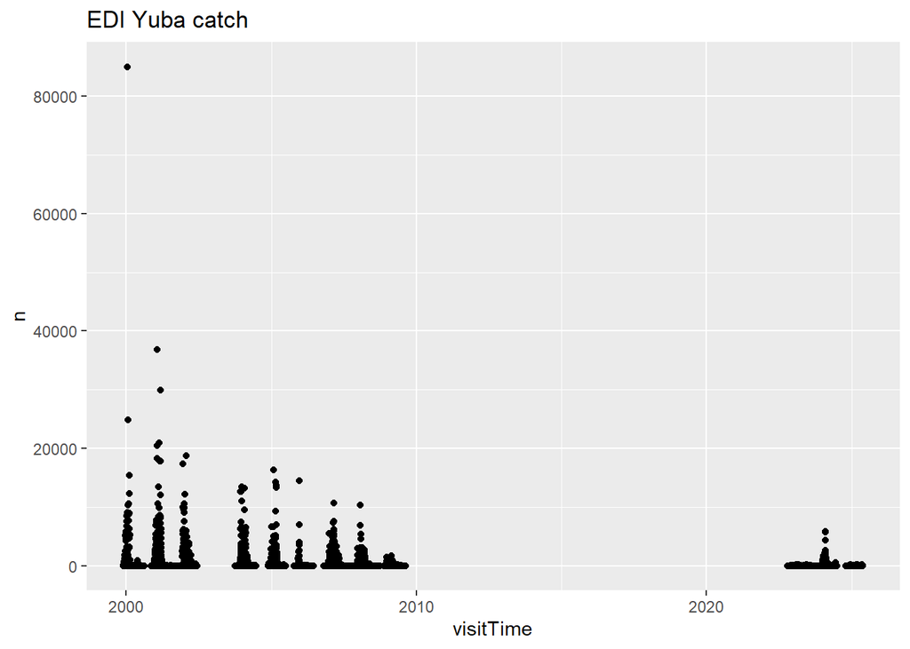

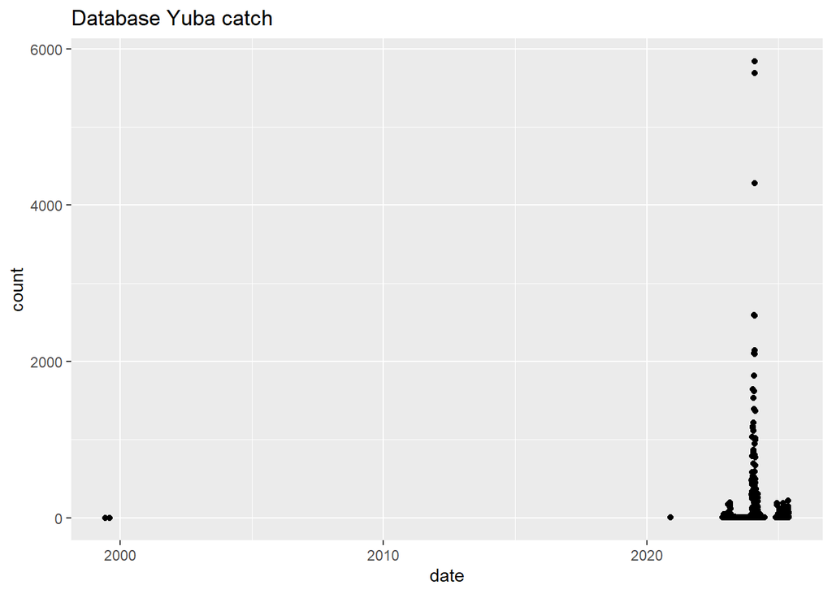

Random pick of data entry to compare between db and EDI

```
## Rows: 1
## Columns: 14
## $ id               <int> 45516139
## $ catch_raw_id     <chr> "16336.0"
## $ trap_location_id <int> 47
## $ date             <date> 2024-01-25
## $ count            <dbl> 1
## $ run_id           <int> 3
## $ lifestage_id     <int> 2
## $ adipose_clipped  <lgl> FALSE
## $ dead             <lgl> NA
## $ fork_length      <dbl> 38
## $ weight           <dbl> NA
## $ actual_count     <lgl> TRUE
## $ updated_at       <dttm> 2025-06-09 08:59:50
## $ stream           <chr> "yuba river"
```

```
## Rows: 1
## Columns: 16
## $ visitTime            <dttm> 2024-01-25 11:31:10
## $ run                  <chr> "Fall"
## $ forkLength           <dbl> 38
## $ lifeStage            <chr> "Fry"
## $ n                    <dbl> 1
## $ siteName             <chr> "Hallwood"
## $ subSiteName          <chr> "Hallwood 1 RR"
## $ fishOrigin           <chr> "Natural"
## $ commonName           <chr> "Chinook salmon"
## $ releaseID            <dbl> 0
## $ ProjectDescriptionID <dbl> 7
## $ trapVisitID          <dbl> 889
## $ visitType            <chr> "Continue trapping"
## $ catchRawID           <dbl> 16336
## $ totalLength          <dbl> NA
## $ actualCount          <chr> "Yes"
```

test 2

```
## Rows: 1
## Columns: 14
## $ id               <int> 45525324
## $ catch_raw_id     <chr> "21795.0"
## $ trap_location_id <int> 48
## $ date             <date> 2024-02-28
## $ count            <dbl> 1
## $ run_id           <int> 3
## $ lifestage_id     <int> 2
## $ adipose_clipped  <lgl> FALSE
## $ dead             <lgl> NA
## $ fork_length      <dbl> 37
## $ weight           <dbl> NA
## $ actual_count     <lgl> TRUE
## $ updated_at       <dttm> 2025-06-09 08:59:50
## $ stream           <chr> "yuba river"
```

```
## Rows: 1
## Columns: 16
## $ visitTime            <dttm> 2024-02-28 10:02:51
## $ run                  <chr> "Fall"
## $ forkLength           <dbl> 37
## $ lifeStage            <chr> "Fry"
## $ n                    <dbl> 1
## $ siteName             <chr> "Hallwood"
## $ subSiteName          <chr> "Hallwood 2 RL"
## $ fishOrigin           <chr> "Natural"
## $ commonName           <chr> "Chinook salmon"
## $ releaseID            <dbl> 0
## $ ProjectDescriptionID <dbl> 7
## $ trapVisitID          <dbl> 977
## $ visitType            <chr> "Continue trapping"
## $ catchRawID           <dbl> 21795
## $ totalLength          <dbl> NA
## $ actualCount          <chr> "Yes"
```

test 3

```
## Rows: 1
## Columns: 14
## $ id               <int> 45502300
## $ catch_raw_id     <chr> "31918.0"
## $ trap_location_id <int> 48
## $ date             <date> 2024-12-27
## $ count            <dbl> 1
## $ run_id           <int> 2
## $ lifestage_id     <int> 2
## $ adipose_clipped  <lgl> FALSE
## $ dead             <lgl> NA
## $ fork_length      <dbl> 39
## $ weight           <dbl> NA
## $ actual_count     <lgl> TRUE
## $ updated_at       <dttm> 2025-06-09 08:59:50
## $ stream           <chr> "yuba river"
```

```
## Rows: 1
## Columns: 16
## $ visitTime            <dttm> 2024-12-27 10:23:29
## $ run                  <chr> "Spring"
## $ forkLength           <dbl> 39
## $ lifeStage            <chr> "Fry"
## $ n                    <dbl> 1
## $ siteName             <chr> "Hallwood"
## $ subSiteName          <chr> "Hallwood 2 RL"
## $ fishOrigin           <chr> "Natural"
## $ commonName           <chr> "Chinook salmon"
## $ releaseID            <dbl> 255
## $ ProjectDescriptionID <dbl> 7
## $ trapVisitID          <dbl> 1485
## $ visitType            <chr> "End trapping"
## $ catchRawID           <dbl> 31918
## $ totalLength          <dbl> NA
## $ actualCount          <chr> "Yes"
```

test 4

```
## Rows: 1
## Columns: 14
## $ id               <int> 45529156
## $ catch_raw_id     <chr> "8830.0"
## $ trap_location_id <int> 47
## $ date             <date> 2023-04-24
## $ count            <dbl> 1
## $ run_id           <int> 3
## $ lifestage_id     <int> 6
## $ adipose_clipped  <lgl> FALSE
## $ dead             <lgl> NA
## $ fork_length      <dbl> 78
## $ weight           <dbl> NA
## $ actual_count     <lgl> TRUE
## $ updated_at       <dttm> 2025-06-09 08:59:50
## $ stream           <chr> "yuba river"
```

```
## Rows: 1
## Columns: 16
## $ visitTime            <dttm> 2023-04-24 09:19:49
## $ run                  <chr> "Fall"
## $ forkLength           <dbl> 78
## $ lifeStage            <chr> "Silvery parr"
## $ n                    <dbl> 1
## $ siteName             <chr> "Hallwood"
## $ subSiteName          <chr> "Hallwood 1 RR"
## $ fishOrigin           <chr> "Natural"
## $ commonName           <chr> "Chinook salmon"
## $ releaseID            <dbl> 0
## $ ProjectDescriptionID <dbl> 7
## $ trapVisitID          <dbl> 392
## $ visitType            <chr> "Continue trapping"
## $ catchRawID           <dbl> 8830
## $ totalLength          <dbl> NA
## $ actualCount          <chr> "Yes"
```

#### trap

**- Findings:** - database has a temporal coverage of 2015 - 2025, and EDI has a data as early as 1999

- Database date range (`trap_visit_time_end`)

```
## Rows: 1,651
## Columns: 22
## $ id                         <int> 2023632, 2023639, 2023646, 2043140, 2043147…
## $ trap_location_id           <int> 79, 79, 79, 79, 79, 79, 49, 79, 79, 79, 49,…
## $ trap_visit_id              <chr> NA, NA, NA, NA, NA, NA, "11", NA, NA, NA, "…
## $ visit_type_id              <int> NA, NA, NA, NA, NA, NA, 2, NA, NA, NA, 2, 2…
## $ trap_visit_time_start      <dttm> NA, NA, NA, NA, NA, NA, 2022-10-25 09:13:4…
## $ trap_visit_time_end        <dttm> NA, NA, 2020-11-27 08:00:00, NA, NA, 2020-…
## $ trap_functioning_id        <int> 2, 5, 5, 2, 5, 5, 2, 2, 5, 5, 2, 2, 2, 2, 2…
## $ in_half_cone_configuration <lgl> TRUE, FALSE, FALSE, TRUE, FALSE, FALSE, NA,…
## $ fish_processed_id          <int> NA, NA, NA, NA, NA, NA, 3, NA, NA, NA, 3, 3…
## $ rpm_start                  <dbl> NA, NA, NA, NA, NA, NA, 1.77, NA, NA, NA, 0…
## $ rpm_end                    <dbl> NA, NA, NA, NA, NA, NA, 1.5, NA, NA, NA, 0.…
## $ total_revolutions          <dbl> NA, NA, NA, NA, NA, NA, NA, NA, NA, NA, 0, …
## $ debris_volume              <dbl> NA, NA, NA, NA, NA, NA, NA, NA, NA, NA, NA,…
## $ debris_level_id            <int> NA, NA, NA, NA, NA, NA, NA, NA, NA, NA, NA,…
## $ discharge                  <dbl> NA, NA, NA, NA, NA, NA, NA, NA, NA, NA, NA,…
## $ water_velocity             <dbl> NA, NA, NA, NA, NA, NA, NA, NA, NA, NA, NA,…
## $ water_temp                 <dbl> NA, NA, NA, NA, NA, NA, 18, NA, NA, NA, 13,…
## $ turbidity                  <dbl> NA, NA, NA, NA, NA, NA, 0.88, NA, NA, NA, 1…
## $ include                    <lgl> FALSE, FALSE, FALSE, FALSE, FALSE, FALSE, T…
## $ updated_at                 <dttm> 2025-06-03 19:15:19, 2025-06-03 19:15:19, …
## $ updated_by                 <chr> "AdminJPE", "AdminJPE", "AdminJPE", "AdminJ…
## $ stream                     <chr> "yuba river", "yuba river", "yuba river", "…
```

```
## [1] "2015-04-15 10:36:13 UTC" "2025-05-23 10:51:30 UTC"
```

```
## Rows: 5,070
## Columns: 14
## $ counterAtEnd          <dbl> NA, NA, NA, NA, NA, NA, NA, NA, NA, NA, NA, NA, …
## $ siteName              <chr> "Hallwood", "Hallwood", "Hallwood", "Hallwood", …
## $ subSiteName           <chr> "Hallwood 1 RR", "Hallwood 1 RR", "Hallwood 1 RR…
## $ rpmRevolutionsAtStart <dbl> NA, NA, NA, NA, NA, NA, NA, NA, NA, NA, NA, NA, …
## $ rpmRevolutionsAtEnd   <dbl> NA, NA, NA, NA, NA, NA, NA, NA, NA, NA, NA, NA, …
## $ waterTemp             <dbl> 11.5, 11.5, 12.0, 12.0, 12.0, 12.0, 11.5, 11.5, …
## $ turbidity             <dbl> NA, NA, NA, NA, NA, NA, NA, NA, NA, NA, NA, NA, …
## $ visitTime             <dttm> 2000-05-07 10:00:00, 2000-05-08 08:00:00, 2000-…
## $ visitType             <chr> "Continue trapping", "Continue trapping", "Conti…
## $ trapFunctioning       <chr> "Not recorded", "Not recorded", "Not recorded", …
## $ fishProcessed         <chr> "Not recorded", "Not recorded", "Not recorded", …
## $ includeCatch          <chr> "Yes", "Yes", "Yes", "Yes", "Yes", "Yes", "Yes",…
## $ projectDescriptionID  <dbl> NA, NA, NA, NA, NA, NA, NA, NA, NA, NA, NA, NA, …
## $ trapVisitID           <dbl> NA, NA, NA, NA, NA, NA, NA, NA, NA, NA, NA, NA, …
```

```
## [1] "1999-11-25 09:00:00 UTC" "2025-05-27 12:30:34 UTC"
```

*water temp*

- 2.7 % of values in the `water_temp` column in DB data are NA.
- 1.1 % of values in the `waterTemp` column in edi data are NA.

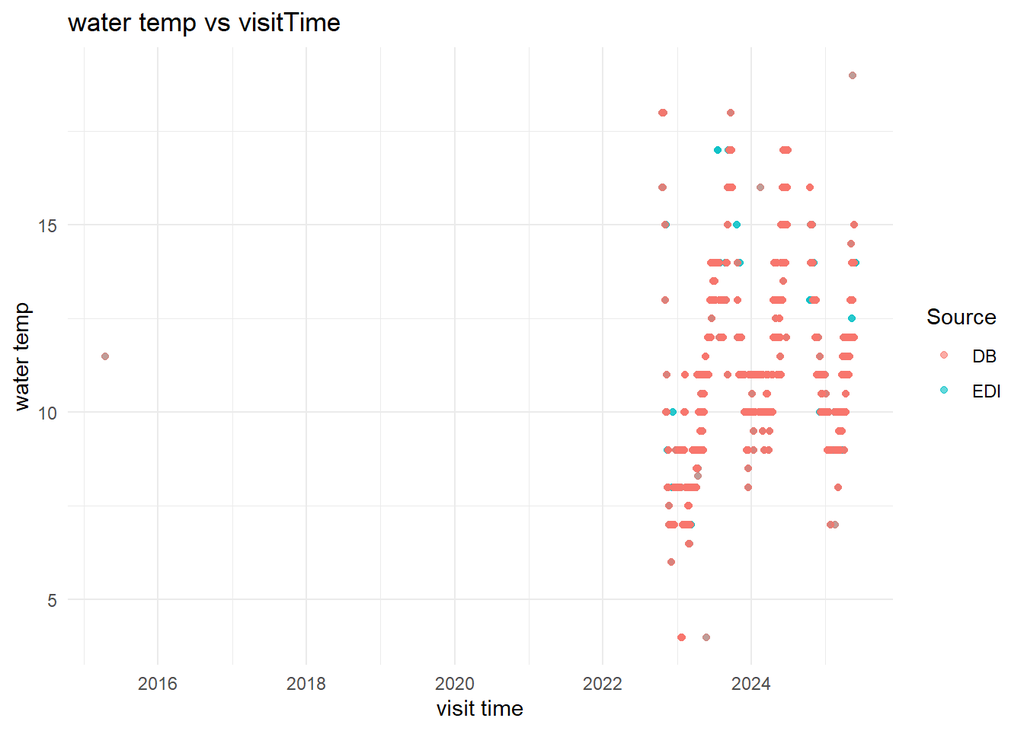

Random pick of data entry to compare between db and EDI

test 1

```
## Rows: 1
## Columns: 23
## $ id                         <int> 2044844
## $ trap_location_id           <int> 49
## $ trap_visit_id              <chr> "11"
## $ visit_type_id              <int> 2
## $ time                       <dttm> 2022-10-25 09:13:43
## $ trap_visit_time_end        <dttm> NA
## $ trap_functioning_id        <int> 2
## $ in_half_cone_configuration <lgl> NA
## $ fish_processed_id          <int> 3
## $ rpm_start                  <dbl> 1.77
## $ rpm_end                    <dbl> 1.5
## $ total_revolutions          <dbl> NA
## $ debris_volume              <dbl> NA
## $ debris_level_id            <int> NA
## $ discharge                  <dbl> NA
## $ water_velocity             <dbl> NA
## $ temp                       <dbl> 18
## $ turbidity                  <dbl> 0.88
## $ include                    <lgl> TRUE
## $ updated_at                 <dttm> 2025-06-09 09:00:13
## $ updated_by                 <chr> "AdminJPE"
## $ stream                     <chr> "yuba river"
## $ source                     <chr> "DB"
```

```
## Rows: 1
## Columns: 15
## $ counterAtEnd          <dbl> NA
## $ siteName              <chr> "Hallwood"
## $ subSiteName           <chr> "Hallwood 3"
## $ rpmRevolutionsAtStart <dbl> 1.77
## $ rpmRevolutionsAtEnd   <dbl> 1.5
## $ temp                  <dbl> 18
## $ turbidity             <dbl> 0.88
## $ time                  <dttm> 2022-10-25 09:13:43
## $ visitType             <chr> "Continue trapping"
## $ trapFunctioning       <chr> "Trap functioning normally"
## $ fishProcessed         <chr> "No fish were caught"
## $ includeCatch          <chr> "Yes"
## $ projectDescriptionID  <dbl> 7
## $ trapVisitID           <dbl> 11
## $ source                <chr> "EDI"
```

test 2

```
## Rows: 1
## Columns: 23
## $ id                         <int> 2045597
## $ trap_location_id           <int> 47
## $ trap_visit_id              <chr> "960"
## $ visit_type_id              <int> 2
## $ time                       <dttm> 2024-02-22 10:55:50
## $ trap_visit_time_end        <dttm> NA
## $ trap_functioning_id        <int> 2
## $ in_half_cone_configuration <lgl> NA
## $ fish_processed_id          <int> 2
## $ rpm_start                  <dbl> 4.1
## $ rpm_end                    <dbl> 3.8
## $ total_revolutions          <dbl> 4560
## $ debris_volume              <dbl> NA
## $ debris_level_id            <int> NA
## $ discharge                  <dbl> NA
## $ water_velocity             <dbl> NA
## $ temp                       <dbl> 10
## $ turbidity                  <dbl> 13.2
## $ include                    <lgl> TRUE
## $ updated_at                 <dttm> 2025-06-09 09:00:13
## $ updated_by                 <chr> "AdminJPE"
## $ stream                     <chr> "yuba river"
## $ source                     <chr> "DB"
```

```
## Rows: 1
## Columns: 15
## $ counterAtEnd          <dbl> 4560
## $ siteName              <chr> "Hallwood"
## $ subSiteName           <chr> "Hallwood 1 RR"
## $ rpmRevolutionsAtStart <dbl> 4.1
## $ rpmRevolutionsAtEnd   <dbl> 3.8
## $ temp                  <dbl> 10
## $ turbidity             <dbl> 13.2
## $ time                  <dttm> 2024-02-22 10:55:50
## $ visitType             <chr> "Continue trapping"
## $ trapFunctioning       <chr> "Trap functioning normally"
## $ fishProcessed         <chr> "Processed fish"
## $ includeCatch          <chr> "Yes"
## $ projectDescriptionID  <dbl> 7
## $ trapVisitID           <dbl> 960
## $ source                <chr> "EDI"
```

test 3

```
## Rows: 1
## Columns: 23
## $ id                         <int> 2045982
## $ trap_location_id           <int> 48
## $ trap_visit_id              <chr> "643"
## $ visit_type_id              <int> 2
## $ time                       <dttm> 2023-08-01 09:52:02
## $ trap_visit_time_end        <dttm> NA
## $ trap_functioning_id        <int> 2
## $ in_half_cone_configuration <lgl> NA
## $ fish_processed_id          <int> 2
## $ rpm_start                  <dbl> 0.9
## $ rpm_end                    <dbl> 0.7
## $ total_revolutions          <dbl> 950
## $ debris_volume              <dbl> NA
## $ debris_level_id            <int> NA
## $ discharge                  <dbl> NA
## $ water_velocity             <dbl> NA
## $ temp                       <dbl> 13
## $ turbidity                  <dbl> 1.22
## $ include                    <lgl> TRUE
## $ updated_at                 <dttm> 2025-06-09 09:00:13
## $ updated_by                 <chr> "AdminJPE"
## $ stream                     <chr> "yuba river"
## $ source                     <chr> "DB"
```

```
## Rows: 1
## Columns: 15
## $ counterAtEnd          <dbl> 950
## $ siteName              <chr> "Hallwood"
## $ subSiteName           <chr> "Hallwood 2 RL"
## $ rpmRevolutionsAtStart <dbl> 0.9
## $ rpmRevolutionsAtEnd   <dbl> 0.7
## $ temp                  <dbl> 13
## $ turbidity             <dbl> 1.22
## $ time                  <dttm> 2023-08-01 09:52:02
## $ visitType             <chr> "Continue trapping"
## $ trapFunctioning       <chr> "Trap functioning normally"
## $ fishProcessed         <chr> "Processed fish"
## $ includeCatch          <chr> "Yes"
## $ projectDescriptionID  <dbl> 7
## $ trapVisitID           <dbl> 643
## $ source                <chr> "EDI"
```

test 4

```
## Rows: 1
## Columns: 23
## $ id                         <int> 2044846
## $ trap_location_id           <int> 49
## $ trap_visit_id              <chr> "16"
## $ visit_type_id              <int> 2
## $ time                       <dttm> 2022-10-27 08:43:54
## $ trap_visit_time_end        <dttm> NA
## $ trap_functioning_id        <int> 2
## $ in_half_cone_configuration <lgl> NA
## $ fish_processed_id          <int> 3
## $ rpm_start                  <dbl> 1.7
## $ rpm_end                    <dbl> 2
## $ total_revolutions          <dbl> 1852
## $ debris_volume              <dbl> NA
## $ debris_level_id            <int> NA
## $ discharge                  <dbl> NA
## $ water_velocity             <dbl> NA
## $ temp                       <dbl> NA
## $ turbidity                  <dbl> 0.58
## $ include                    <lgl> TRUE
## $ updated_at                 <dttm> 2025-06-09 09:00:13
## $ updated_by                 <chr> "AdminJPE"
## $ stream                     <chr> "yuba river"
## $ source                     <chr> "DB"
```

```
## Rows: 1
## Columns: 15
## $ counterAtEnd          <dbl> 1852
## $ siteName              <chr> "Hallwood"
## $ subSiteName           <chr> "Hallwood 3"
## $ rpmRevolutionsAtStart <dbl> 1.7
## $ rpmRevolutionsAtEnd   <dbl> 2
## $ temp                  <dbl> NA
## $ turbidity             <dbl> 0.58
## $ time                  <dttm> 2022-10-27 08:43:54
## $ visitType             <chr> "Continue trapping"
## $ trapFunctioning       <chr> "Trap functioning normally"
## $ fishProcessed         <chr> "No fish were caught"
## $ includeCatch          <chr> "Yes"
## $ projectDescriptionID  <dbl> 7
## $ trapVisitID           <dbl> 16
## $ source                <chr> "EDI"
```